# Assignment Problems for Cohort 2

# Problem 34-1

**Location:** `assignment-problems/cartesian_product.py`

**Estimated Time:** 45 minutes

**Grading:** 10 points

Write a function `cartesian_product(arrays)` that computes the [Cartesian product](https://en.wikipedia.org/wiki/Cartesian_product) of all the lists in `arrays`.

```
>>> cartesian_product([['a'], [1,2,3], ['Y','Z']])
[['a',1,'Y'], ['a',1,'Z'], ['a',2,'Y'], ['a',2,'Z'], ['a',3,'Y'], ['a',3,'Z']]
```

**NOTE: This is a reasonably short function if you use the following procedure. You'll probably have to think a bit in order to get the implementation correct, though. (Make sure to post for help if you get stuck!)**

1. Create a variable `points` that will be a list of all the points in the cartesian product. Initially, set `points` to consist of a single empty point: `points = [[]]`.
2. For each array in the input, create a new list of points.
   - The new set of points can be constructed by looping through each existing point and, for each existing point, adding several new points.
     - For a given point, the new points can be constructed by appending each element of the array onto a copy of the given point.
3. Return the list of points.

**Worked Example:**

[output not shown]

**Watch out!** If you write `new_point = old_point`, then this just makes it so that `new_point` refers to `old_point`. So then whenever you change one of those variables, the other will change as well.

To actually make a separate independent copy, you can use `new_point = list(old_point)`. That way, when you change one of the variables, it will have no effect on the other.

# Problem 34-2

**Locations:**

> `machine-learning/src/gradient_descent.py`  
> `machine-learning/tests/test_gradient_descent.py`

**Estimated Time:** 60 minutes

**Grading:** 10 points

Write a class `GradientDescent` that performs gradient descent on an input function with any number of arguments. This builds on top of Problem 25-1.

- **Tip:** if you have a function `f(x,y,z)` and a list `args = [0,5,3]`, then you can pass `f(*args)` to evaluate `f(0,5,3)`.**
- **Tip:** to get the number of variables that a function accepts as input, use `f.__code__.co_argcount`. For example:

  ```
  >>> def f(x,y): return x**2 + y**2
  >>> f.__code__.co_argcount
  2
  ```

Assert that your `GradientDescent` passses the following tests. (Make sure to post for help if you get stuck!)

**Note: the tests below are shown rounded to 3 decimal places. You should do the rounding in your `assert` statement, NOT in your `GradientDescent` class.**

```
>>> def single_variable_function(x):
        return (x-1)**2
>>> def two_variable_function(x, y):
        return (x-1)**2 + (y-1)**3
>>> def three_variable_function(x, y, z):
        return (x-1)**2 + (y-1)**3 + (z-1)**4
>>> def six_variable_function(x1, x2, x3, x4, x5, x6):
        return (x1-1)**2 + (x2-1)**3 + (x3-1)**4 + x4 + 2*x5 + 3*x6

>>> minimizer = GradientDescent(f=single_variable_function, initial_point=[0])
>>> minimizer.point
[0]
>>> ans = minimizer.compute_gradient(delta=0.01)
[-2.000] # rounded to 5 decimal places
>>> minimizer.descend(alpha=0.001, delta=0.01, num_steps=1)
>>> minimizer.point
[0.002]

>>> minimizer = GradientDescent(f=two_variable_function, initial_point=[0,0])
>>> minimizer.point
[0,0]
>>> minimizer.compute_gradient(delta=0.01)
[-2.000, 3.000]
>>> minimizer.descend(alpha=0.001, delta=0.01, num_steps=1)
>>> minimizer.point
[0.002, -0.003]

>>> minimizer = GradientDescent(f=three_variable_function, initial_point=[0,0,0])
>>> minimizer.point
[0,0,0]
>>> minimizer.compute_gradient(delta=0.01)
[-2.000, 3.000, -4.000]
>>> minimizer.descend(alpha=0.001, delta=0.01, num_steps=1)
>>> minimizer.point
[0.002, -0.003, 0.004]

>>> minimizer = GradientDescent(f=six_variable_function, initial_point=[0,0,0,0,0,0])
>>> minimizer.point
[0,0,0,0,0,0]
>>> minimizer.compute_gradient(delta=0.01)
[-2.000, 3.000, -4.000, 1.000, 2.000, 3.000]
>>> minimizer.descend(alpha=0.001, delta=0.01, num_steps=1)
>>> minimizer.point
[0.002, -0.003, 0.004, -0.001, -0.002, -0.003]
```

**Make sure to push your finished code to Github with a commit message that says what you added/changed (you should always commit your code to Github after an assignment).**

# Problem 34-3

**Estimated Time:** 60 min

**Location:** Overleaf

**Grading:** 10 points

- Complete Module 7 of [Sololearn's C++ Course](https://www.sololearn.com/Course/CPlusPlus/). Take screenshots of the completed modules, with your user profile showing, and submit them along with the assignment.
- Complete queries 1-15 in Module 1 of the [SQL Zoo](https://napier.sqlzoo.net/). [Here's a reference](https://www.w3schools.com/sql/sql_like.asp) for the LIKE operator, which will come in handy.

Take a screenshot of each successful query and put them in an overleaf doc. When a query is successful, you'll see a smiley face appear. Your screenshots should look like this:

[figure not shown]

# Problem 34-4

Take a look at all your assignments so far in this course. If there are any assignments with low grades, that you haven't already resubmitted, then be sure to resubmit them.

Also, if you haven't already, submit quiz corrections for all of the quizzes we've had so far!

# Problem 33-1

**Location:** Overleaf

**Estimated Time:** 60 minutes

**Grading:** 10 points

Suppose you are again given the following dataset:

```
data = [(1,0.2), (2,0.25), (3,0.5)]
```

Fit a *logistic* regression model $y=\dfrac{1}{1+e^{ax+b}}$ **by hand**.

1. Re-express the model in the form $ax+b = \text{some function of }y$ (i.e. isolate $ax+b$ in the logistic regression model). Hint: your function of $y$ will involve $\ln.$
2. Set up a system of equations and turn the system into a matrix equation.
3. Find the best approximation to the solution of that matrix equation by using the pseudoinverse.
4. Substituting your solution for the coefficients of the model, and **plot the model along with the 3 given data points on the same graph** to ensure that the model fits the data points well.

Show all of your steps. No code allowed in steps 1, 2, and 3! But in step 4, you can write a Python script for the final plot (or make the plot in latex).

**Note:** To plot points on a graph in Python, you can use the following:

```
plt.plot([1, 2, 3, 4], [1, 4, 9, 16]) # plot line segments
plt.plot([1, 2, 3, 4], [1, 4, 9, 16], 'ro') # plot red ('r') circles ('o')
```

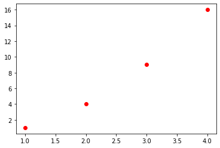

```python
import matplotlib.pyplot as plt
plt.plot([1, 2, 3, 4], [1, 4, 9, 16], 'ro') # plot red ('r') circles ('o')
```

# Problem 33-2

**Location:** Overleaf

**Estimated Time:** 30 minutes

**Grading:** 6 points

**a.** (2 points) Given that $X \sim p(x),$ where $p(x)$ is a continuous distribution, prove that for any real number $a$ we have $E[aX] = aE[X].$

- You should start by writing $E[aX]$ as an integral, manipulating it, and then simplifying the result into $aE[X].$ The manipulation will just be 1 step.

**b.** (4 points) Given that $X \sim p(x)$ where $p(x)$ is a continuous probability distribution, prove the identity $\text{Var}[X] = E[X^2] - E[X]^2.$

# Problem 33-3

**Estimated Time:** 15 min

**Grading:** 4 points

- Complete Module 6 of [Sololearn's C++ Course](https://www.sololearn.com/Course/CPlusPlus/). Take a screenshot of the completed module, with your user profile showing, and submit it along with the assignment.

# Problem 32-1

**Estimated time:** 60 min

**Grading:** 15 points

**Locations:**

> `machine-learning/src/linear_regressor.py`  
> `machine-learning/tests/test_linear_regressor.py`

Create a class `LinearRegressor` that works as follows. **Make sure your code is general.** In other words, do not assume the dataset always consists of 3 points, do not assume the independent variable is always named `'progress'`, etc.

```
>>> df = DataFrame.from_array(
    [[1,0.2],
     [2,0.25],
     [3,0.5]],
    columns = ['hours worked', 'progress']
)
>>> regressor = LinearRegressor(df, dependent_variable='progress')
>>> regressor.coefficients
[0.01667, 0.15] # meaning that the model is progress = 0.01667 + 0.15 * (hours worked)
# these coefficients are rounded, but you should not round except for
# in your assert statement

>>> regressor.predict({'hours worked': 4})
0.61667
```

# Problem 32-2

**Estimated Time:** 15 min

**Grading:** 5 points

(Taken from *Introduction to Probability: Statistics and Random Processes* by Hossein Pishro-Nik)

**a.**

[figure not shown]

- Tip: for (b), compute $1-P(\textrm{complement}).$ Here, the complement is the event that you get no aces.

**b.**

[figure not shown]

- Tip: again, compute $1-P(\textrm{complement}).$

# Problem 32-3

**Estimated Time:** 30 min

**Grading:** 10 points

- Complete Module 5 of [Sololearn's C++ Course](https://www.sololearn.com/Course/CPlusPlus/). Take a screenshot of each completed module, with your user profile showing, and submit both screenshots along with the assignment.
- Complete Module 4 of [Sololearn's SQL Course](https://www.sololearn.com/Course/SQL/). Take a screenshot of the completed module, with your user profile showing, and submit it along with the assignment.

# Problem 31-1

**Estimated Time:** 60 min

**Grading:** 20 points

**a.**

[figure not shown]

- Just count up the number of outcomes in favor, and divide by the total number of possible outcomes

**b.**

[figure not shown]

- [Here is a link to a similar problem, worked out.](https://www.youtube.com/watch?v=xVCDqm6IhtU)
- Remember that $A^C$ is the "complement" of $A,$ meaning all the space that is NOT included in $A.$
- Remember that $A - B = \{ a \in A \, | \, a \not \in B \}.$ For example, $\{ 1, 2, 3 \} - \{2, 4, 6 \} = \{ 1, 3 \}.$

**c.**

[figure not shown]

- "With replacement" means that each time a ball is drawn, it is put back in for the next draw. So, it would be possible to draw the same ball more than once.
- Multiply the following: (number of ways to choose k red balls in a sample of 20) $\times$ (probability of getting k red balls in a row) $\times$ (probability of getting 20-k green balls in a row)
- This is very similar to flipping a biased coin, if you think of "red ball" as "heads" and "green ball" as "tails": (number of ways to get k heads in 20 flips) $\times$ (probability of getting k heads in a row) $\times$ (probability of getting 20-k tails in a row)

**d.**

[figure not shown]

- "Without replacement" means that each time a ball is drawn, it is NOT put back in for the next draw. So, it would NOT be possible to draw the same ball more than once.
- It's easiest to do this problem if you think of just counting up the number of possibilities in favor, and dividing by the total number of possibilities.
  - Possibilities in favor: (number of ways to choose k of the 30 red balls) $\times$ (number of ways to choose 20-k of the 70 green balls)
  - Total number of possibilities: (number of ways to choose 20 of the 100 balls)

**e.**

[figure not shown]

- CDF stands for "Cumulative Distribution Function" and is defined as $\textrm{CDF}(x) = P(X \leq x).$
- For example, $\textrm{CDF}(6) = P(X \leq 6) = 0.3 + 0.2 = 0.5.$
- You're just plotting the function $y=\textrm{CDF}(x).$ You can just draw a picture and put it in your Overleaf doc as an image.

# Problem 31-2

**Estimated Time:** 30 min

**Grading:** 10 points

- Complete Module 4 of [Sololearn's C++ Course](https://www.sololearn.com/Course/CPlusPlus/). Take a screenshot of each completed module, with your user profile showing, and submit both screenshots along with the assignment.
- Complete Module 3 of [Sololearn's SQL Course](https://www.sololearn.com/Course/SQL/). Take a screenshot of the completed module, with your user profile showing, and submit it along with the assignment.

# Problem 30-1

**Grading:** 10 points

(Taken from *Introduction to Probability: Statistics and Random Processes* by Hossein Pishro-Nik)

**a.**

[figure not shown]

**b.**

[figure not shown]

- **Check:** you should get a result of $0.1813.$ If you get stuck, then [here's a link](https://math.stackexchange.com/questions/193099/conditional-probabilities-involving-the-exponential-distribution/193130) to a similar example, worked out.

**c.**

[figure not shown]

# Problem 30-2

**Location:** `assignment-problems/doubly_linked_list.py`

**Grading:** 10 points

Create a class `DoublyLinkedList` that is similar to `LinkedList`, except that each `Node` has an additional attribute, `prev`, which returns the previous node. (It is the opposite of the `next` attribute.)

Make sure that `prev` is updated correctly in each of the operations.

Assert that the following test passes:

```
>>> doubly_linked_list = DoublyLinkedList('a')
>>> doubly_linked_list.append('c')
>>> doubly_linked_list.append('d')
>>> doubly_linked_list.append('e')
>>> doubly_linked_list.insert('b',1)
>>> doubly_linked_list.delete(3)

Note: at this point, the list looks like this:
a <--> b <--> c <--> e

>>> current_node = doubly_linked_list.get_node(3)
>>> node_values = [current_node.data]
>>> for _ in range(3):
        current_node = current_node.prev
        node_values.append(current_node.data)
>>> node_values
['e', 'c', 'b', 'a']
```

# Problem 30-3

**Grading:** 10 points

- Complete Module 3 of [Sololearn's C++ Course](https://www.sololearn.com/Course/CPlusPlus/). Take a screenshot of each completed module, with your user profile showing, and submit both screenshots along with the assignment.
- Complete Module 2 of [Sololearn's SQL Course](https://www.sololearn.com/Course/SQL/). Take a screenshot of the completed module, with your user profile showing, and submit it along with the assignment.

# Problem 29-1

**Location:** Overleaf

**Grading:** 10 points

The **Poisson distribution** can be used to model how many times an event will occur within some continuous interval of time, given that occurrences of an event are independent of one another.

Its probability function is given by \begin{align*} p_\lambda(n) = \dfrac{\lambda^n e^{-\lambda}}{n!}, \quad n \in \left\{ 0, 1, 2, \ldots \right\}, \end{align*}

where $\lambda$ is the mean number of events that occur in the particular time interval.

**SUPER IMPORTANT:** Manipulating the Poisson distribution involves using infinite sums. However, these sums can be easily expressed using the Maclaurin series for $e^x\mathbin{:}$

\begin{align*} e^x = 1 + x + \dfrac{x^2}{2!} + \dfrac{x^3}{3!} + \ldots \end{align*}

**a.** Consider the Poisson distribution defined by $$p_2(n) = \dfrac{2^n e^{-2}}{n!}.$$ Show that this is a valid probability distribution, i.e. all the probability sums to $1.$

**b.** Given that $N \sim p_2,$ compute $P(10 < N \leq 12).$ Leave your answer in exact form, and don't expand out the factorials. Pay close attention to the "less than" vs "less than or equal to" symbols.

**c.** Given that $N \sim p_2,$ compute $E[N].$

- Using the Maclaurin series for $e^x,$ your answer should simplify to $2.$
- When doing your series manipulations, **don't** use sigma notation. Instead, write out the first several terms of the series, followed by "dot dot dot", as shown in the Maclaurin series under the "SUPER IMPORTANT" label.

**d.** Given that $N \sim p_2,$ compute $\text{Var}[N].$ Using the Maclaurin series for $e^x,$ your answer should come out to a nice clean integer.

- Using the Maclaurin series for $e^x,$ your answer should again simplify to $2.$
- Again, when doing your series manipulations, **don't** use sigma notation. Instead, write out the first several terms of the series, followed by "dot dot dot", as shown in the Maclaurin series under the "SUPER IMPORTANT" label.
- Tip: try multiplying out the binomial before you expand out the sums. Those 3 sums will be easier to compute, individually $$\begin{align*} e^{-2} \sum_{n=0}^\infty (n-2)^2 \dfrac{2^n}{n!} = e^{-2} \sum_{n=0}^\infty n^2 \cdot \dfrac{2^n}{n!} - e^{-2} \sum_{n=0}^\infty 4n \cdot \dfrac{2^n}{n!} + e^{-2} \sum_{n=0}^\infty 4 \cdot \dfrac{2^n}{n!} \end{align*}$$

# Problem 29-2

**Location:** `machine-learning/tests/test_data_frame.py`

**Grading:** 10 points

Implement the following functionality in your `DataFrame`, and **assert that these tests pass.**

**a.** Loading an array. You'll need to use `@classmethod` for this one ([read about it here](https://stackabuse.com/pythons-classmethod-and-staticmethod-explained/)).

```
>>> columns = ['firstname', 'lastname', 'age']
>>> arr = [['Kevin', 'Fray', 5],
           ['Charles', 'Trapp', 17],
           ['Anna', 'Smith', 13],
           ['Sylvia', 'Mendez', 9]]
>>> df = DataFrame.from_array(arr, columns)
```

**b.** Selecting rows which satisfy a particular condition (given as a lambda function)

```
>>> df.select_rows_where(
    lambda row: len(row['firstname']) >= len(row['lastname'])
                and row['age'] > 10
    ).to_array()
[['Charles', 'Trapp', 17]]
```

- **Note:** It's true that if you're just working with a plain old array, you can't do stuff like `row['firstname']`. But we're working with a DataFrame class, which means we've got some creative freedom. You'll have to find way to convert a row array to a row dictionary, behind the scenes. In other words, make a function `convert_row_from_array_to_dict` that takes a row `['Kevin', 'Fray', 5]` and converts it to

  ```
  {
    'firstname': 'Kevin',
    'lastname': 'Fray',
    'age': 5
  }
  ```

  before you apply the lambda function.

**c.** Ordering the rows by given column

```
>>> df.order_by('age', ascending=True).to_array()
[['Kevin', 'Fray', 5],
['Sylvia', 'Mendez', 9],
['Anna', 'Smith', 13],
['Charles', 'Trapp', 17]]

>>> df.order_by('firstname', ascending=False).to_array()
[['Sylvia', 'Mendez', 9],
['Kevin', 'Fray', 5],
['Charles', 'Trapp', 17],
['Anna', 'Smith', 13]]
```

# Problem 29-3

**Grading:** 5 points

Complete Module 1 of [Sololearn's SQL Course](https://www.sololearn.com/Course/SQL/). Take a screenshot of the completed module, with your user profile showing, and submit it along with the assignment.

# Problem 28-1

**Location:** Overleaf

**Grading:** 10 points

Suppose you are given the following dataset:

```
data = [(1,0.2), (2,0.25), (3,0.5)]
```

Fit a linear regression model $y=a+bx$ **by hand** by

1. setting up a system of equations,
2. turning the system into a matrix equation,
3. finding the best approximation to the solution of that matrix equation by using the pseudoinverse, and
4. substituting your solution for the coefficients of the model.

Show all of your steps. No code allowed!

# Problem 28-2

**Grading:** 5 points

Create an `apply` method in your `DataFrame`, that passes the following test:

```
>>> data_dict = {
    'Pete': [1, 0, 1, 0],
    'John': [2, 1, 0, 2],
    'Sarah': [3, 1, 4, 0]
}

>>> df1 = DataFrame(data_dict, column_order = ['Pete', 'John', 'Sarah'])
>>> df2 = df1.apply('John', lambda x: 7 * x)
>>> df2.data_dict
{
    'Pete': [1, 0, 1, 0],
    'John': [14, 7, 0, 14],
    'Sarah': [3, 1, 4, 0]
}
```

# Problem 28-3

**Location:** Overleaf

**Grading:** 5 points

If you didn't get 100% on problem 27-3, revise it and submit it again on this assignment. If you already got 100%, then these 5 points are free.

# Problem 28-4

**Grading:** 5 points

Complete Module 1 AND Module 2 of [Sololearn's C++ Course](https://www.sololearn.com/Course/CPlusPlus/). Take a screenshot of each completed module, with your user profile showing, and submit both screenshots along with the assignment.

[figure not shown]

# Problem 27-1

**Grading:** 2 points

In your `Matrix` class, overload `__rmul__`and `__pow__` so that you pass the following tests:

```
>>> A = Matrix([[1, 1, 0],
                [2, -1, 0],
                [0, 0, 3]])

>>> B = 0.1 * A
>>> B.elements
[[0.1, 0.1, 0],
 [0.2, -0.1, 0],
 [0, 0, 0.3]]

>>> C = A**3
>>> C.elements
[[3, 3, 0],
 [6, -3, 0],
 [0, 0, 27]]
```

# Problem 27-2

**Grading:** 5 points

Update `EulerEstimator` to make plots:

```
>>> euler = EulerEstimator(derivative = lambda t: t+1)

>>> euler.plot(point=(-5,10), step_size=0.1, num_steps=100)

for this example, the plot should look like the parabola
y = 0.5x^2 + x + 2.5
on the domain -5 <= x <= 5
```

# Problem 27-3

**Location:** Overleaf

**Grading:** 10 points

Suppose you toss a coin $10$ times and get the result $\text{HHHHT HHHHH}.$ From this result, you estimate that the coin is biased and generally lands on heads $90\%$ of the time. But how sure can you be? Let's quantify it.

**a.** **Compute the likelihood** $P(\text{HHHHT HHHHH}\, | \, k)$ where $P(H)=k.$ Remember that the likelihood is just the probability of getting the result $\text{HHHHT HHHHH}$ under the assumption that $P(H)=k.$ Your answer should be expressed in terms of $k.$

**b.** The likelihood $P(\text{HHHHT HHHHH} \, | \, k)$ can *almost* be interpreted as a probability distribution for $k.$ The only problem is that it doesn't integrate to $1.$

Create a probability distribution $P(k \, | \, \text{HHHHT HHHHH})$ that is proportional to the likelihood $P(\text{HHHHT HHHHH} \, | \, k).$ In other words, find the function $P(k)$ such that

$$ P(k \, | \, \text{HHHHT HHHHH}) = c \cdot P(\text{HHHHT HHHHH} \, | \, k) $$

for some constant $c,$ and $\displaystyle \int_0^1 P(k \, | \, \text{HHHHT HHHHH}) = 1.$

- Note: the distribution $P(k \, | \, \text{HHHHT HHHHH})$ is called the "posterior" distribution because it represents the probability distribution of $k$ *after* we have observed the event $\text{HHHHT HHHHH}.$
- The probability distribution of $k$ *before* we observed the event is called the "prior" distribution and in this case was given by $P(k) \sim \mathcal{U}[0,1]$ since we did not know anything about whether or not the coin is biased (or how biased it is).

**c.** Using the prior distribution $P(k) \sim \mathcal{U}[0,1],$ what was the prior probability that the coin was biased towards heads? In other words, what was $P(k > 0.5)?$

**d.** Using the posterior distribution $P(k \, | \, \text{HHHHT HHHHH}),$ what was the posterior probability that the coin was biased towards heads? In other words, what is $P(k > 0.5 \, | \, \text{HHHHT HHHHH})?$

**e.** Compare your answers in parts (c) and (d). Did the probability that the coin was biased towards heads increase or decrease, after observing the sequence of flips? Why does this make intuitive sense?

**f.** Using the posterior distribution, what is the most probable value of $k?$ In other words, what is value of $k$ at which $P(k \, | \, \text{HHHHT HHHHH})$ reaches a maximum? Show your work using the first or second derivative test.

**g.** Why does your answer to (f) make sense? What's the intuition here?

**h.** What is the probability that the bias $k$ lies within $0.05$ of your answer to part (g)? In other words, what is the probability that $0.85 < k < 0.95?$

**i.** Fill in the blank: you can be $99\%$ sure that $P(H)$ is at least $\_\_\_.$

Here's a bit more context about the whole situation and what we're trying to do by calculating these things:

- We're flipping a coin and we don't know if it's biased.
- We let k represent the probability of getting heads. Initially we don't know if the coin is biased, so we'll just say that k has equal probability of being anything. It might be 0.5 (unbiased), or it might be 0.1 (tails more often), or it might be 0.9 (heads more often), or anything. So the probability of k, denoted P(k). This is called our "prior" distribution because it represents our belief "prior" to flipping the coin.
- After we flip the coin 10 times and get HHHHT HHHHH, we gain information about how biased our coin is. It looks like it's way biased towards heads. So we need to update our probability distribution. We will call the updated distribution P(k | HHHHT HHHHH), which is "the probability of k given that we got the flips HHHHT HHHHH". This is called our "posterior" distribution because it represents our belief "posterior" or "after" flipping the coin.
- But how do we actually get the posterior distribution? It turns out that (as we will prove later), the posterior distribution is proportional to the likelihood of observing the data that we did. In other words, posterior = c *likelihood, which becomes P(k | HHHHT HHHHH) = c* P(HHHHT HHHHH | k).
- Now, for any probability calculations involving k, we can get more accurate probability measurements by using the posterior distribution P(k | HHHT HHHHH) instead of the prior distribution P(k).

# Problem 27-4

**Grading:** this assignment will not be graded unless you do this problem

When you submit your assignment, include a link to your github so that I can review your code. I'm going to put in grade for code quality. The code quality will be graded again at the end of the semester, so you will have an opportunity fix anything that's costing you points before the end of the semester.

# Problem 26-1

**Grading:** 10 points

**Note:** If you're approaching it the right way, this problem will be really quick (15 minutes or less to do both parts).

**a.** In your `Matrix` class, implement a method `exponent`.

- Remember that to take the exponent of a matrix, you need to repeatedly multiply the matrix by itself using *matrix multiplication*. (Don't just exponentiate each element separately.)

Include the following test in `tests/test_matrix.py`.

```
>>> A = Matrix([[1, 1, 0],
                [2, -1, 0],
                [0, 0, 3]])
>>> A.exponent(3).elements
[[3, 3, 0],
 [6, -3, 0],
 [0, 0, 27]]
```

**b.** Also, [overload](https://www.geeksforgeeks.org/operator-overloading-in-python/) the following operators:

- `+` (`__add__`) for matrix addition,
- `-` (`__sub__`) for matrix subtraction,
- `*` (`__mul__`) for scalar multiplication,
- `@` (`__matmul__`) for matrix multiplication,
- `==` (`__eq__`) for equality

Include the following test in `tests/test_matrix.py`.

```
>>> A = Matrix(
    [[1,0,2,0,3],
    [0,4,0,5,0],
    [6,0,7,0,8],
    [-1,-2,-3,-4,-5]]
    )

>>> A_t = A.transpose()
>>> A_t.elements
[[ 1,  0,  6, -1],
 [ 0,  4,  0, -2],
 [ 2,  0,  7, -3],
 [ 0,  5,  0, -4],
 [ 3,  0,  8, -5]]

>>> B = A_t @ A
>>> B.elements
[[38,  2, 47,  4, 56],
 [ 2, 20,  6, 28, 10],
 [47,  6, 62, 12, 77],
 [ 4, 28, 12, 41, 20],
 [56, 10, 77, 20, 98]]

>>> C = B * 0.1
>>> C.elements
[[3.8,  .2, 4.7,  .4, 5.6],
 [ .2, 2.0,  .6, 2.8, 1.0],
 [4.7,  .6, 6.2, 1.2, 7.7],
 [ .4, 2.8, 1.2, 4.1, 2.0],
 [5.6, 1.0, 7.7, 2.0, 9.8]]

>>> D = B - C
>>> D.elements
[[34.2,  1.8, 42.3,  3.6, 50.4]
 [ 1.8, 18. ,  5.4, 25.2,  9. ]
 [42.3,  5.4, 55.8, 10.8, 69.3]
 [ 3.6, 25.2, 10.8, 36.9, 18. ]
 [50.4,  9. , 69.3, 18. , 88.2]]

>>> E = D + C
>>> E.elements
[[38,  2, 47,  4, 56],
 [ 2, 20,  6, 28, 10],
 [47,  6, 62, 12, 77],
 [ 4, 28, 12, 41, 20],
 [56, 10, 77, 20, 98]]

>>> E == B
True

>> E == C
False
```

# Problem 26-2

**Grading:** 10 points

**a.** Extend your `Matrix` class to include a method `cofactor_method_determinant()` that computes the determinant recursively using the cofactor method.

- [Here](https://www.chilimath.com/lessons/advanced-algebra/determinant-3x3-matrix/) is an example of using the cofactor method on a $3 \times 3$ matrix
- [Here](http://mathcentral.uregina.ca/QQ/database/QQ.09.07/h/rav1.html) is an example of using the cofactor method on a $4 \times 4$ matrix
- *Don't* cram everything into the method `cofactor_method_determinant()`. You will need to write at least one helper function (if you think about the cofactor method, you should be able to realize what the helper function would need to do).

**b.** Ensure that your `cofactor_method_determinant()` passes the same exact tests that you already have for your `determinant()`.

**c.** In a file `machine-learning/analysis/rref_vs_cofactor_method_determinant.py`, create a $10 \times 10$ matrix and compute the determinant using `determinant()` and then `cofactor_method_determinant()`. Which one is faster, and why do you think it's faster? **Write your answer as a comment in your code.**

# Problem 26-3

**Location**: Overleaf

**Grading:** 10 points for correct answers *with supporting work*

**Note:** For every question, you need to justify your answer, but you *don't* have to show every single step your work. For example, if you're computing a probability, it would be sufficient to write down the statement of the probability, the corresponding integral, the antiderivative, and then the answer. For example, if

$$ X \sim p(x) = \dfrac{1}{\pi} x \sin x, \quad 0 \leq x \leq \pi,$$

then to compute $P\left( X > \dfrac{\pi}{2} \right),$ all you would have to write down is

$$\begin{align*} P\left( X > \dfrac{\pi}{2} \right) &= \int_{\pi/2}^\pi \dfrac{1}{\pi} x \sin x \, \textrm dx \\ &= \dfrac{1}{\pi} \left[ \sin x - x \cos x \right]_{\pi/2}^\pi \quad \textrm{(IBP)} \\ &= \dfrac{\pi - 1}{\pi}. \end{align*}$$

**Part 1**

Suppose that you take a bus to work every day. Bus A arrives at 8am but is $x$ minutes late with $x \sim U(0,20).$ Bus B arrives at 8:10 but with $x \sim U(0,10).$ The bus ride is 20 minutes and you need to arrive at work by 8:30.

- Remember that $U(a,b)$ means the uniform distribution on $[a,b].$ See problem 23-2 if you need a refresher on exponential distributions.
- Recall the formulas for the mean and variance of uniform distributions: If $X \sim \mathcal{U}(a,b),$ then $\textrm{E}[X] = \dfrac{a+b}{2}$ and $\textrm{Var}(X) = \dfrac{(b-a)^2}{12}.$ You can use these formulas without any further justification.

**a.** If you take bus A, what time do you expect to arrive at work? Justify your answer.

**b.** If you take bus B, what time do you expect to arrive at work? Justify your answer.

**c.** If you take bus A, what is the probability that you will arrive on time to work? Justify your answer.

**d.** If you take bus B, what is the probability that you will arrive on time to work? Justify your answer.

**Part 2**

Continuing the scenario above, there is a third option that you can use to get to work: you can jump into a wormhole and (usually) come out almost instantly at the other side. The only issue is that time runs differently inside the wormhole, and while you're probably going to arrive at the other end very quickly, there's a small chance that you could get stuck in there for a really long time.

The number of **seconds** it takes you to come out the other end of the wormhole follows an exponential distribution $\textrm{Exp}(\lambda = 4).$

- See problem 23-2 if you need a refresher on exponential distributions.
- Recall the formulas for the mean and variance of exponential distributions: If $X \sim \textrm{Exp}(\lambda),$ then $\textrm{E}[X] = \dfrac{1}{\lambda}$ and $\textrm{Var}(X) = \dfrac{1}{\lambda^2}.$ You can use these formulas without any further justification.

**a.** How long do you expect it to take you to come out of the wormhole? Justify your answer.

**b.** What's the probability of taking longer than a second to come out of the wormhole? Justify your answer.

**c.** Fill in the blank: the probability of coming out of the wormhole within ___ seconds is $99.999\%.$ Justify your answer.

**d.** Your friend says that you shouldn't use the wormhole because there's always a chance that you might get stuck in it for over a day, and if you use the wormhole often, then that'll probably happen sometime within your lifetime. Is this a reasonable fear? Why or why not? Justify your answer by computing the probability that you'll get stuck in the wormhole for over a day if you use the wormhole $10$ times each day for $80$ years.

- Hint: It's easier to start by computing the probability that you *won't* get stuck in the wormhole for over a day on any given trip through the wormhole, and then use that to compute the probability that you *won't* get stuck in the wormhole for over a day if you use the wormhole $10$ times each day for $80$ years.

# Problem 25-1

**Location:** `assignment_problems/gradient_descent.py`

**Grading:** 10 points

Extend your gradient descent function

```
gradient_descent(f,initial_point,alpha=0.01,delta=0.0001,num_iterations=10000)
```

to work on **2-variable functions**. The `initial_point` will take the form $(x_0, y_0),$ and you will repeatedly update your guesses as follows:

\begin{align*} x_{n+1} &= x_n - \alpha f_x(x_n, y_n) \\ y_{n+1} &= y_n - \alpha f_y(x_n, y_n) \end{align*}

To estimate the partial derivatives $f_x(x_n,y_n)$ and $f_y(x_n,y_n),$ you will again use a central difference quotient:

\begin{align*} f_x(x_n, y_n) &\approx \dfrac{f(x_n+ 0.5 \, \delta, y_n) - f(x_n- 0.5 \, \delta, y_n)}{\delta} \\ f_y(x_n, y_n) &\approx \dfrac{f(x_n, y_n+ 0.5 \, \delta) - f(x_n, y_n- 0.5 \, \delta)}{\delta} \\ \end{align*}

**a.** State the minimum of the function $f(x,y)=1+x^2+y^2.$ Put this as a comment in your code. (Don't use gradient descent yet -- you should be able to tell the minimum just by looking at the function.)

**b.** Use your gradient descent function to minimize $f(x,y)=1+x^2+y^2$ starting with the initial guess $(1,2).$

- Be sure to set the `num_iterations` high enough that you get very close to the actual minimum. Your result should match up with what you said in part (a).

**c.** Find the minimum of the function $f(x,y)=1+x^2 + 2x +y^2 - 9y$ using algebra. (You should complete the square -- [here's a refresher if you need it](https://math.stackexchange.com/questions/2746595/finding-the-equation-of-the-ellipse-by-completing-the-square).) Show the steps of your algebra as a comment in your code.

**d.** Use your gradient descent function to minimize $f(x,y)=1+x^2 + 2x +y^2 - 9y$ starting with the initial guess $(0,0).$

- Again, be sure to set the `num_iterations` high enough that you get very close to the actual minimum. Your result should match up with what you said in part (c).

# Problem 25-2

**Location:** `machine-learning/src/dataframe.py`

**Grading:** 10 points

Create a class `DataFrame` that implements the following tests:

```
>>> data_dict = {
    'Pete': [1, 0, 1, 0],
    'John': [2, 1, 0, 2],
    'Sarah': [3, 1, 4, 0]
}

>>> df1 = DataFrame(data_dict, column_order = ['Pete', 'John', 'Sarah'])
>>> df1.data_dict
{
    'Pete': [1, 0, 1, 0],
    'John': [2, 1, 0, 2],
    'Sarah': [3, 1, 4, 0]
}

>>> df1.columns
['Pete', 'John', 'Sarah']

>>> df1.to_array()
[[1, 2, 3]
 [0, 1, 1]
 [1, 0, 4]
 [0, 2, 0]]

>>> df2 = df1.select_columns(['Sarah', 'Pete'])
>>> df2.to_array()
[[3, 1],
 [1, 0],
 [4, 1],
 [0, 0]]

>>> df2.columns
['Sarah', 'Pete']

>>> df3 = df1.select_rows([1,3])
>>> df3.to_array()
[[0, 1, 1]
 [0, 2, 0]]
```

# Problem 24-1

**Grading:** 10 points

**Locations:**

> `simulation/src/euler_estimator.py`  
> `simulation/tests/test_euler_estimator.py`

Here's a refresher of Euler estimation from AP Calc BC. Suppose that $x'(t) = t+1,$ and we're starting at a point $(1,4),$ and we want to estimate the value of $x(3)$ using a step size of $\Delta t = 0.5.$

The key idea is that $$ x'(t) \approx \dfrac{\Delta x}{\Delta t} \quad \Rightarrow \quad \Delta x \approx x'(t) \Delta t. $$

Let's carry out the Euler estimation:

- We start at the point $(1,4).$ The slope at this point is $x'(1)=2,$ and $t$ is increasing by a step size of $\Delta t = 0.5,$ so $x$ will increase by $$\begin{align*} \Delta x &\approx x'(1) \Delta t \\ &= (2)(0.5) \\ &= 1. \end{align*}$$
- Now we're at the point $(1.5,5).$ The slope at this point is $x'(1.5)=2.5,$ and $t$ is increasing by a step size of $\Delta t = 0.5,$ so $x$ will increase by $$\begin{align*} \Delta x &\approx x'(1.5) \Delta t \\ &= (2.5)(0.5) \\ &= 1.25. \end{align*}$$
- Now we're at the point $(2,6.25).$ The slope at this point is $x'(2)=3,$ and $t$ is increasing by a step size of $\Delta t = 0.5,$ so $x$ will increase by $$\begin{align*} \Delta x &\approx x'(2) \Delta t \\ &= (3)(0.5) \\ &= 1.5. \end{align*}$$
- Now we're at the point $(2.5,7.75).$ The slope at this point is $x'(2.5)=3.5,$ and $t$ is increasing by a step size of $\Delta t = 0.5,$ so $x$ will increase by $$\begin{align*} \Delta x &\approx x'(2.5) \Delta t \\ &= (3.5)(0.5) \\ &= 1.75. \end{align*}$$
- Finally, we reach the point $(3,9.5).$ Therefore, we conclude that $x(3) \approx 9.5.$

**Here is your task.** Create a Github repository `simulation` and create a file `simulation/src/euler_estimator.py` that contains a class `EulerEstimator`. Write this class so that it passes the following tests, which should be placed in `simulation/tests/test_euler_estimator.py`.

```
>>> euler = EulerEstimator(derivative = (lambda t: t+1))

>>> euler.calc_derivative_at_point((1,4))
2

>>> euler.step_forward(point=(1,4), step_size=0.5)
(1.5, 5)

>>> euler.calc_estimated_points(point=(1,4), step_size=0.5, num_steps=4)
[
    (1, 4), # starting point
    (1.5, 5), # after 1st step
    (2, 6.25), # after 2nd step
    (2.5, 7.75), # after 3rd step
    (3, 9.5) # after 4th step
]
```

# Problem 24-2

**Location:** Overleaf

**Grading:** 5 points

Suppose we have a coin that lands on heads with probability $k$ and tails with probability $1-k.$

We flip the coin $5$ times and get $HHTTH.$

**a.** Compute the likelihood of the observed outcome if the coin were fair (i.e. $k=0.5$). SHOW YOUR WORK!

\begin{align*} P(\text{HHTTH} \, | \, k=0.5) &= P(\text{H}\, | \, k=0.5) \cdot P(\text{H}\, | \, k=0.5) \cdot P(\text{T}\, | \, k=0.5) \cdot P(\text{T}\, | \, k=0.5) \cdot P(\text{H}\, | \, k=0.5) \\ &= \, ? \end{align*}

```
\begin{align*}
P(\text{HHTTH} \, | \, k=0.5) &= P(\text{H}\, | \, k=0.5) \cdot P(\text{H}\, | \, k=0.5) \cdot P(\text{T}\, | \, k=0.5) \cdot P(\text{T}\, | \, k=0.5) \cdot P(\text{H}\, | \, k=0.5) \\
&= \, ?
\end{align*}
```

*Check: your answer should come out to $0.03125 \, .$*

**b.** Compute the likelihood of the observed outcome if the coin were slightly biased towards heads, say $k=0.55.$ SHOW YOUR WORK!

\begin{align*} P(\text{HHTTH} \, | \, k=0.55) &= P(\text{H}\, | \, k=0.55) \cdot P(\text{H}\, | \, k=0.55) \cdot P(\text{T}\, | \, k=0.55) \cdot P(\text{T}\, | \, k=0.55) \cdot P(\text{H}\, | \, k=0.55) \\ &= \, ? \end{align*}

*Check: your answer should round to $0.03369 \, .$*

**c.** Compute the likelihood of the observed outcome for a general value of $p.$ Your answer should be a function of $k.$

\begin{align*} P(\text{HHTTH} \, | \, k) &= P(\text{H}\, | \, k) \cdot P(\text{H}\, | \, k) \cdot P(\text{T}\, | \, k) \cdot P(\text{T}\, | \, k) \cdot P(\text{H}\, | \, k) \\ &= \, ? \end{align*}

*Check: When you plug in $k=0.5,$ you should get the answer from part (a), and when you plug in $k=0.55,$ you should get the answer from part (b).*

**d.** Plot a graph of $P(\text{HHTTH} \, | \, k)$ for $0 \leq k \leq 1,$ and **include the graph in your writeup.** (The [template](https://eurisko-us.github.io/resources/#latex-commandments) includes an example of how to insert an image into a latex document.)

For your plot, you can either use `tikzpicture` as shown in the template, or you can create a Python plot and insert it as a `png`.

# Problem 23-1

Implement the algorithm `merge_sort` that you carried by hand in Assignment 22. Make sure to follow the pseudocode that was provided. Assert that your function passes the following test:

```
>>> merge_sort([4,8,7,7,4,2,3,1])
[1,2,3,4,4,7,7,8]
```

# Problem 23-2

**Location:** Overleaf

**Grading:** 8 points

**Note:** Points will be deducted for poor latex quality. If you're writing up your latex and anything looks off, make sure to post about it so you can fix it before you submit. [FOLLOW THE LATEX COMMANDMENTS!](https://eurisko-us.github.io/resources/#latex-commandments)

**PART 1**

Consider the general exponential distribution defined by $$p_\lambda(x) = \begin{cases} \lambda e^{-\lambda x} & x \geq 0 \\ 0 & x < 0 \end{cases}.$$

**a.** Using integration, show that this is a valid distribution, i.e. all the probability integrates to $1.$

**b.** Given that $X \sim p_\lambda,$ compute $P(0 < X < 1).$

**c.** Given that $X \sim p_\lambda,$ compute $\mathrm{E}[X].$

**d.** Given that $X \sim p_\lambda,$ compute $\text{Var}[X].$

**Note:** Your answers should match those from Assignment 20 when you substitute $\lambda = 2.$

**PART 2**

Consider the general uniform distribution on the interval $[a,b].$ It takes the following form for some constant $k\mathbin{:}$

$$p(x) = \begin{cases} k & x \in [a,b] \\ 0 & x \not\in [a,b] \end{cases}$$

a) Find the value of $k$ such that $p(x)$ is a valid probability distribution. Your answer should be in terms of $a$ and $b.$

b) Given that $X \sim p,$ compute the cumulative distribution $P(X \leq x).$ Your answer should be a piecewise function:

$$P(X \leq x) = \begin{cases} \_\_\_ &\text{ if } x < a \\ \_\_\_ &\text{ if } a \leq x \leq b \\ \_\_\_ &\text{ if } b < x \end{cases}$$

c) Given that $X \sim p,$ compute $\mathrm{E}[X].$

d) Given that $X \sim p,$ compute $\text{Var}[X].$

**Note:** Your answers should match those from Assignment 21 when you substitute $a = 3, b=7.$

# Problem 22-1

**Location:** `assignment_problems/gradient_descent.py`

**Grading:** 10 points

Write a function `gradient_descent(f,x0,alpha=0.01,delta=0.0001,iterations=10000)` that uses *gradient descent* to estimate the minimum of $f(x),$ given the initial guess $x=x_0.$ [Here's a visualization of how it works.](https://www.youtube.com/watch?v=ClotAJHZ3oE)

The *gradient descent* algorithm involves repeatedly updating the guess by moving slightly down the slope of the function:

$$x_{n+1} = x_n - \alpha f'(x_n),$$

where $\alpha$ (alpha) is a constant called the *learning rate*.

Like before, you should estimate $f'(x_n)$ using a central difference quotient,

$$f'(x_n) \approx \dfrac{f(x_n+0.5 \, \delta) - f(x_n- 0.5 \, \delta)}{\delta},$$

where $\delta$ (delta) is chosen as a very small constant. (For our cases, $\delta = 0.001$ should be sufficiently small.)

You should stop updating the guess after `iterations=10000` times through the updating process.

**a.** Test `gradient_descent` on a simple example: estimate the minimum value of

$$f(x)=x^2+2x+1$$

using the initial guess $x_0 = 0.$ (Note: do **not** work out the derivative by hand! You should estimate it numerically.)

**b.** Use `gradient_descent` to estimate the minimum value of

$$f(x)=\frac{x^{2}+\cos\left(x\right)}{e^{\sin\left(x\right)}}$$

using the initial guess $x_0 = 0.$ (Note: do **not** work out the derivative by hand! You should estimate it numerically.) Check your answer by plotting the graph on Desmos.

# Problem 22-2

Here is pseudocode for a sorting algorithm called `merge_sort`:

```
merge_sort(input list):
    if the input list consists of more than one element:
        break up the input list into its left and right halves
        sort the left and right halves by recursively calling merge_sort
        merge the two sorted halves
        return the result
    otherwise, if the input list consists of only one element, then it is already sorted,
        and you can just return it.
```

Here is an example of how `merge_sort` sorts a list:

```
input list:[6,9,7,4,2,1,8,5]
break it in half: [6,9,7,4] [2,1,8,5]
use merge_sort recursively to sort the two halves

    input list: [6,9,7,4]
    break it in half: [6,9] [7,4]
    use merge_sort recursively to sort the two halves

        input list: [6,9]
        break it in half: [6] [9]
        the two halves have only one element each, so they are already sorted
        so we can merge them to get [6,9]

        input list: [7,4]
        break it in half: [7] [4]
        the two halves have only one element each, so they are already sorted
        so we can merge them to get [4,7]

    now we have two sorted lists [6,9] and [4,7]
    so we can merge them to get [4,6,7,9]

    input list: [2,1,8,5]
    break it in half: [2,1] [8,5]
    use merge_sort recursively to sort the two halves

        input list: [2,1]
        break it in half: [2] [1]
        the two halves have only one element each, so they are already sorted
        so we can merge them to get [1,2]

        input list: [8,5]
        break it in half: [8] [5]
        the two halves have only one element each, so they are already sorted
        so we can merge them to get [5,8]

    now we have two sorted lists [1,2] and [5,8]
    so we can merge them to get [1,2,5,8]

now we have two sorted lists [4,6,7,9] and [1,2,5,8]
so we can merge them to get [1,2,4,5,6,7,8,9]
```

**Here is your problem:** Manually walk through the steps used to sort the list `[4,8,7,7,4,2,3,1]` using `merge_sort`. Use the same format as is shown above.

# Problem 21-1

**Location:** `assignment-problems/merge_sort.py`

**Grading:** 10 points

Write a function `merge(x,y)` that combines two sorted lists `x` and `y` so that the result itself is also sorted. You should run through each list in parallel, keeping track of a separate index in each list, and repeatedly bring a copy of the smallest element into the output list.

```
>>> merge([-2,1,4,4,4,5,7],[-1,6,6])
[-2,-1,1,4,4,4,5,6,6,7]
```

# Problem 21-2

**Location:** Overleaf

**Grading:** 10 points

**Note:** Points will be deducted for poor latex quality. If you're writing up your latex and anything looks off, make sure to post about it so you can fix it before you submit. [FOLLOW THE LATEX COMMANDMENTS!](https://eurisko-us.github.io/resources/#latex-commandments)

**SHOW YOUR WORK!**

A **uniform distribution** on the interval $[3,7]$ is a probability distribution $p(x)$ that takes the following form for some constant $k\mathbin{:}$

$$p(x) = \begin{cases} k & x \in [3,7] \\ 0 & x \not\in [3,7] \end{cases}$$

It is also $\mathcal{U}[3,7].$ So, to say that $X \sim \mathcal{U}[3,7],$ is to say that $X \sim p$ for the function $p$ shown above.

**a.** Find the value of $k$ such that $p(x)$ is a valid probability distribution. (Remember that for a function to be a valid probability distribution, it must integrate to 1.)

**b.** Given that $X \sim \mathcal{U}[3,7],$ compute $\text{E}[X].$

- Check: does your result make intuitive sense? If you pick a bunch of numbers from the interval $[3,7],$ and all of those numbers are equally likely choices, then what would you expect to be the average of the numbers you pick?

**c.** Given that $X \sim \mathcal{U}[3,7],$ compute $\text{Var}[X].$

- You should get $\dfrac{4}{3}.$

# Problem 21-3

**Grading:** 10 points

Extend your `Matrix` class to include a method `determinant()` that computes the determinant.

You should do this by copying the same code as in your `rref()` method, but this time, keep track of the scaling factors by which you divide the rows of the matrix, and keep track of the total number of row swaps.

- If the reduced row echelon form DOES NOT come out to the identity, then the determinant is zero.
- If the reduced row echelon form DOES come out to the identity, then:
  - the magnitude of the determinant is the product of the scaling factors
  - the sign of the determinant is $(-1)$ raised to the power of the number of row swaps

Assert that your `determinant()` method passes the following tests:

```
>>> A = Matrix(elements = [[1,2]
                           [3,4]])
>>> ans = A.determinant()
>>> round(ans,6)
-2

>>> A = Matrix(elements = [[1,2,0.5]
                           [3,4,-1],
                           [8,7,-2]])
>>> ans = A.determinant()
>>> round(ans,6)
-10.5

>>> A = Matrix(elements = [[1,2,0.5,0,1,0],
                           [3,4,-1,1,0,1],
                           [8,7,-2,1,1,1],
                           [-1,1,0,1,0,1],
                           [0,0.35,0,-5,1,1],
                           [1,1,1,1,1,0]])
>>> ans = A.determinant()
>>> round(ans,6)
-37.3

>>> A = Matrix(elements = [[1,2,0.5,0,1,0],
                           [3,4,-1,1,0,1],
                           [8,7,-2,1,1,1],
                           [-1,1,0,1,0,1],
                           [0,0.35,0,-5,1,1],
                           [1,1,1,1,1,0],
                           [2,3,1.5,1,2,0]])
>>> ans = A.determinant()
Error: cannot take determinant of a non-square matrix

>>> A = Matrix(elements = [[1,2,0.5,0,1,0,1],
                           [3,4,-1,1,0,1,0],
                           [8,7,-2,1,1,1,0],
                           [-1,1,0,1,0,1,0],
                           [0,0.35,0,-5,1,1,0],
                           [1,1,1,1,1,0,0],
                           [2,3,1.5,1,2,0,1]])
>>> ans = A.determinant()
>>> round(ans,6)
0
```

# Problem 20-1

**Location:** Overleaf

**Note:** Points will be deducted for poor latex quality. If you're writing up your latex and anything looks off, make sure to post about it so you can fix it before you submit. [FOLLOW THE LATEX COMMANDMENTS!](https://eurisko-us.github.io/resources/#latex-commandments)

Continuous distributions are defined similarly to discrete distributions. There are only 2 big differences:

- We use an integral to compute expectation: if $X \sim p,$ then $$E[X] = \int_{-\infty}^\infty x \, p(x) \, \mathrm{d}x.$$
- We talk about probability on an interval rather than at a point: if $X \sim p,$ then $$P(a < X \leq b) = \int_a^b p(x) \, \mathrm{d}x$$

**Grading:** 1 point per correct answer *with supporting work*

Consider the exponential distribution defined by $$p_2(x) = \begin{cases} 2 e^{-2 x} & x \geq 0 \\ 0 & x < 0 \end{cases}.$$

**a.** Using integration, show that this is a valid distribution, i.e. all the probability integrates to $1.$

**b.** Given that $X \sim p_2,$ compute $P(0 < X \leq 1).$

- You should get a result of $1-e^{-2}.$

**c.** Given that $X \sim p_2,$ compute $E[X].$

- You should get a result of $\dfrac{1}{2}.$

**d.** Given that $X \sim p_2,$ compute $\text{Var}[X].$

- You should get a result of $\dfrac{1}{4}.$

# Problem 20-2

**Grading:** 4 points

Extend your `LinkedList` to have two additional methods:

- `delete(index)` - delete the node at the given `index`
- `insert(new_data, index)` - insert a node at the given `index`, containing the given `new_data`

```
>>> linked_list = LinkedList('a')
>>> linked_list.append('b')
>>> linked_list.append('c')
>>> linked_list.append('d')
>>> linked_list.append('e')
>>> linked_list.length()
5
>>> linked_list.print_data()
a
b
c
d
e

>>> linked_list.get_node(2).data
'c'
>>> linked_list.delete(2)
>>> linked_list.length()
4
>>> linked_list.get_node(2).data
'd'
>>> linked_list.print()
a
b
d
e

>>> linked_list.insert('f', 2)
>>> linked_list.length()
5
>>> linked_list.get_node(2).data
'f'
>>> linked_list.print()
a
b
f
d
e
```

# Problem 19-1

**Location:** `assignment-problems/zero_of_tangent_line.py`

**a.** (1 point) Write a function `estimate_derivative(f, c, delta)` that estimates the derivative of the function `f(x)` at the point `x=c` using a symmetric difference quotient:

$$ \text{estimate_derivative}(f,c,\delta) = \dfrac{f(c + 0.5 \, \delta) - f(c - 0.5 \, \delta)}{\delta} $$

**b.** (4 points) Using your function `estimate_derivative`, generalize your functions `zero_of_tangent_line` and `estimate_solution` to work for any input function `f(x)`. They should now have the following inputs:

- `zero_of_tangent_line(f, c, delta)` - compute the zero of the tangent line to the function `f(x)` at the point `x=c`, using a symmetric difference quotient with parameter `delta`
- `estimate_solution(f, initial_guess, delta, precision)` - estimate the zero of `f(x)` by starting with `initial_guess` and repeatedly calling `zero_of_tangent_line` (with parameter `delta`) until the next guess is within `precision` of the previous guess.

**Note:** You should no longer hard-code the derivative. Instead, you'll use `estimate_derivative`, which should work on any function that is passed in as input.

Assert that your code passes the following tests:

```
>>> def f(x):
        return x**3 + x - 1

>>> answer = estimate_derivative(f, 0.5, 0.001)
>>> round(answer,6)
1.75

>>> answer = zero_of_tangent_line(f, 0.5, 0.001)
>>> round(answer,6)
0.714286

>>> answer = estimate_solution(f, 0.5, 0.001, 0.01)
>>> round(answer, 6)
0.682328
```

# Problem 19-2

**Location:** Overleaf

**Grading:** 7 points

To say that a random variable $N$ follows a probability distribution $p(n),$ is to say that $P(N=n) = p(n).$ Symbolically, we write $X \sim p.$

The **expected value** (also known as the **mean**) of a random variable $N \sim p$ is defined as the weighted sum of possible values, where the weights are given by the probability.

- In other words, $E[N] = \sum n \cdot p(n).$

The **variance** of a random variable is the expected squared deviation from the mean.

- In other words, $\text{Var}[N] = E[(N-E[N])^2]$

**Warning: No points will be given if you don't show your work.**

**PART 1** (1 point per correct answer *with supporting work*)

**a.** Write the probability distribution $p_{4}(n)$ for getting $n$ heads on $4$ coin flips, where the coin is a fair coin (i.e. it lands on heads with probability $0.5$).

**b.** Let $N$ be the number of heads in $4$ coin flips. Then $N \sim p_{4}.$ Intuitively, what is the expected value of $N?$ Explain the reasoning behind your intuition.

**c.** Compute the expected value of $N,$ *using the definition* $E[N] = \sum n \cdot p(n).$

- The answer you get should match your answer from (b).

**d.** Compute the variance of $N,$ *using the definition* $\text{Var}[N] = E[(N-E[N])^2].$

- Your answer should come out to $1.$

**Part 2** (1 point per correct answer *with supporting work*)

**a.** Write the probability distribution $p_{4,k}(n)$ for getting $n$ heads on $4$ coin flips, where the coin is a **biased** coin that lands on heads with probability $k.$

- If you substitute $k=0.5,$ you should get the same result that you did in part 1a.

**b.** Let $N$ be the number of heads in $4$ coin flips of a biased coin. Then $N\sim p_{4,k}.$ Intuitively, what is the expected value of $N?$ Your answer should be in terms of $k.$ Explain the reasoning behind your intuition.

- If you substitute $k=0.5,$ you should get the same result that you did in part 1b.

**c.** Compute the expected value of $N,$ *using the definition* $E[N] = \sum n \cdot p(n).$

- The answer you get should match your answer from (b).

# Problem 18-1

**Location:** `assignment-problems/approximations_of_randomness.py`

**Grading:** 5 points

During class, each person created a distribution of coin flips.

```
flips = {
    'Justin S': 'HTTH HHTT TTHH TTTH HHTH TTHT HHHH THHT THTT HTHH TTTT HTHT TTHH THTH HTTH HHTH HHHT TTTH HTTH HTHT',
    'Nathan R': 'HTTH HHTH HTTT HTHH HTTH HHHH TTHH TTHT THTT HTHT HHTH TTTT THHT HTTH HTHH THHH HTTH THTT HHHT HTHH',
    'Justin H': 'HHHT HHTH HHTT THHT HTTT HTTT HHHT HTTT TTTT HTHT THHH TTHT TTHH HTHT TTTT HHHH THHH THTH HHHH THHT',
    'Nathan A': 'HTTH HHHH THHH TTTH HTTT THTT HTHT THHT HTTH TTTT HHHH TTHH HHTH TTTH HHHH THTT HTHT TTTT HHTT HHTT',
    'Cayden': 'HTHT HHTT HTTH THTH THHT TTHH HHHH TTTH HHHT HTTT TTHT HHTH HTHH THTT HHHH THTT HTTT HTHH TTTT HTTH',
    'Maia': 'HTHH THTH HTTH TTTT TTHT HHHH HHTT THHH TTHH HHTH THHT HHHH THTT HHTH HTHT TTHH TTHH HHHH TTTT HHHT',
    'Spencer': 'HHHT HTTH HTTT HTHH THTT TTHT TTTT HTTH HHTH TTHT TTHH HTHT THHT TTHT THTT THTH HTTH THHT TTTH HHHH',
    'Charlie': 'HHHH HHHT HHTT HTTT TTTT TTTH TTHH THHH THTH HTHT HHTH HTHH TTHT THTT THTH TTHT HTHT THHT HTTH THTH',
    'Anton': 'HHTH THTH TTTT HTTH THTT TTTH THHH TTHH THHT HHHH TTHT HTTT THTH HHHT HHTH HHHH TTTH HTHT TTTT HHTT',
    'William': 'THTT HHHT HTTH THHT THTH HHHT TTTH HHTH THTH HTHT HHHT TTHT HHHT THTT HHTT TTHH HHTH TTTT THTH TTHT'
}
```

**a.** Treating these coin flips as simulations of 20 samples of 4 flips, compute the KL divergence between each simulation and the true distribution. Print out your results sorted from "best approximation of randomness" to "worst approximation of randomness".

**b.** Whose coin flips were the best approximation of truly random coin flips?

# Problem 18-2

**Grading:** 5 points

Extend your class `Node` class to have an additional attribute `index` that is set by the `LinkedList`. The head node in the `LinkedList` will have index `0`, the next node will have index `1`, and so on.

Extend your class `LinkedList` to have the following methods:

- `push(new_data)` - insert a new node at the head of the linked list, containing the `new_data`
- `get_node(index)` - get the node at `index`

```
>>> linked_list = LinkedList('b')
>>> linked_list.append('e')
>>> linked_list.append('f')
>>> linked_list.push('a')
>>> linked_list.length()
4

>>> linked_list.head.index
0
>>> linked_list.head.next.index
1
>>> linked_list.head.next.next.index
2
>>> linked_list.head.next.next.next.index
3

>>> linked_list.get_node(0).data
'a'
>>> linked_list.get_node(1).data
'b'
>>> linked_list.get_node(2).data
'e'
>>> linked_list.get_node(3).data
'f'
```

# Problem 17-1

**Location:** `assignment-problems/zero_of_tangent_line.py`

Notice that we can approximate a zero of a function by repeatedly computing the zero of the tangent line:

[figure not shown]

**a.** (2 points) Create a function `zero_of_tangent_line(c)` that computes the zero of the tangent line to the function $f(x)=x^3+x-1$ at the point $x=c.$

Assert that your code passes the following test:

```
>>> answer = zero_of_tangent_line(0.5)
>>> round(answer,6)
0.714286
```

**b.** (2 points) Create a function `estimate_solution(initial_guess, precision)` that estimates the solution to $f(x) = x^3+x-1$ by starting with `initial_guess` and repeatedly calling `zero_of_tangent_line` until the next guess is within `precision` of the previous guess.

Asser that your code passes the following test:

```
>>> answer = estimate_solution(0.5, 0.01)
>>> round(answer, 6)
0.682328
```

# Problem 17-2

**Locations:**

> `machine-learning/src/matrix.py`  
> `machine-learning/tests/test_matrix.py`

**Grading:** 4 points

Extend your `Matrix` class to include a method `inverse()` that computes the inverse matrix using [Gaussian elimination](https://en.wikipedia.org/wiki/Gaussian_elimination#Finding_the_inverse_of_a_matrix) (i.e. your `rref` method).

You should do the following:

1. Start with your matrix $A.$
2. Augment $A$ with the identity matrix, to create a matrix $[A | I].$
3. Call reduced row echelon form on your augmented matrix. If the matrix is invertible, then you will get a result $[I|A^{-1}].$
4. Get the inverse $A^{-1}$ from the row-reduced augmented matrix $[I|A^{-1}].$

If the matrix is not invertible, print a message that explains why -- is it be cause it's singular (i.e. square but has linearly dependent rows), or because it's non-square?

**Assert that your `inverse` method passes the following tests:**

```
>>> A = Matrix([[1, 2],
                [3, 4]])
>>> A_inv = A.inverse()
>>> A_inv.elements
[[-2,   1],
 [1.5, -0.5]]

>>> A = Matrix([[1,   2,  3],
                [1,   0, -1],
                [0.5, 0,  0]])
>>> A_inv = A.inverse()
>>> A_inv.elements
[[0,   0,    2],
 [0.5, 1.5, -4],
 [0,  -1,    2]]

>>> A = Matrix([[1, 2, 3, 0],
                [1, 0, 1, 0],
                [0, 1, 0, 0])
>>> A_inv = A.inverse()
Error: cannot invert a non-square matrix

>>> A = Matrix([[1, 2, 3],
                [3, 2, 1],
                [1, 1, 1])
>>> A_inv = A.inverse()
Error: cannot invert a singular matrix
```

# Problem 16-1

**Location:** `assignment-problems/count_compression.py`

**a.** (2 points) Write a function `count_compression(string)` that takes a string and compresses it into a list of tuples, where each tuple indicates the count of times a particular symbol was repeated.

```
>>> count_compression('aaabbcaaaa')
[('a',3), ('b',2), ('c',1), ('a',4)]
>>> count_compression('22344444')
[('2',2), ('3',1), ('4',5)]
```

**b.** (2 points) Write a function `count_decompression(compressed_string)` that decompresses a compressed string to return the original result.

```
>>> count_decompression([('a',3), ('b',2), ('c',1), ('a',4)])
'aaabbcaaaa'
>>> count_decompression([('2',2), ('3',1), ('4',5)])
'22344444'
```

# Problem 16-2

**Location:** `assignment-problems/linked_list.py`

**Grading:** 6 points

Create a class `LinkedList` and a class `Node` which together implement a [singly linked list](https://www.cs.cmu.edu/~adamchik/15-121/lectures/Linked%20Lists/linked%20lists.html). A singly linked list is just bunch of `Node`s connected up in a line.

- The class `LinkedList` should have **exactly one** attribute:
  - `head`: gives the node at the beginning of the linked list
- Each node should have **exactly two** attributes:
  - `data`: returns the contents of the node
  - `next`: returns the next node
- `LinkedList` should have **exactly three** methods:
  - `print_data()`: prints the data of the nodes, starting at the head
  - `length()`: returns the number of nodes in the linked list
  - `append()`: appends a new node to the tail of the linked list

**Don't use any Python lists, anywhere.**

Assert that your `Node` class passes the following tests:

```
>>> A = Node(4)
>>> A.data
4
>>> A.next
None
>>> B = Node(8)
>>> A.next = B
>>> A.next.data
8
```

Assert that your `LinkedList` class passes the following tests:

```
>>> linked_list = LinkedList(4)
>>> linked_list.head.data
4
>>> linked_list.append(8)
>>> linked_list.head.next.data
8
>>> linked_list.append(9)
>>> linked_list.print_data()
4
8
9
>>> linked_list.length()
3
```

# Problem 16-3

**Grading:** 5 points

Make sure your `rref()` method works.

- If it already does, then you are done with this problem and you get a free 5 points.
- If it doesn't, you need to fix it this weekend. The next assignment will have a problem that builds on it, so if you don't have it working, you're going to start digging yourself into a hole.
  - To debug, use the same method I demonstrated in class on Wednesday: print out everything that's going on, and match it up with the log. Take a look at the recording if you need a refresher on how to do this.
  - Post on Slack about any issues you have while debugging, that you can't figure out. I'm happy to look at your code if needed, provided that you've already printed everything out and identified where things first start looking different from the log.

# Problem 15-1

**Location:** Write your answers in LaTeX on Overleaf.com using [this template](https://www.overleaf.com/read/wjmgkxpccvpj).

**PART A**

*The following statements are **false**. For each statement, explain why it is false, and give a concrete counterexample that illustrates that it is false.*

1. (1 point) If you push 3 elements onto the stack, and then pop off 2 elements, you end up with the last element you pushed.
2. (1 point) If you push 3 elements onto a queue, and then dequeue 2 elements, you end up with the first element you pushed.
3. (2 points) Swap sort and simple sort both involve repeatedly comparing two elements. For any given list, the number of pairs of elements that need to be compared by each algorithm is exactly the same.

**PART B** (4 points)

*The following statement is **true**. First, give a concrete example on which the statement holds true. Then, construct a thorough proof.*

Say we flip a coin $n$ times. Let $\widehat{P}(x)$ be the probability of getting $x$ heads according to a Monte Carlo simulation with $N$ samples. Then

$$\widehat{P}(0) + \widehat{P}(1) + \widehat{P}(2) + \cdots + \widehat{P}(n) = 1.$$

# Problem 15-2

**Locations:**

> `machine-learning/src/matrix.py`  
> `machine-learning/tests/test_matrix.py`

**Grading:** 4 points for each method with tests

In your `Matrix` class, write methods `augment(other_matrix)`, `get_rows(row_nums)`, and `get_columns(col_nums)` that satisfy the following tests:

```
>>> A = Matrix([
    [1, 2,   3,  4],
    [5, 6,   7,  8],
    [9, 10, 11, 12]
])
>>> B = Matrix([
    [13, 14],
    [15, 16],
    [17, 18]
])

>>> A_augmented = A.augment(B)
>>> A_augmented.elements
[
    [1, 2,   3,  4, 13, 14],
    [5, 6,   7,  8, 15, 16],
    [9, 10, 11, 12, 17, 18]
]

>>> rows_02 = A_augmented.get_rows([0, 2])
>>> rows_02.elements
[
    [1, 2,   3,  4, 13, 14],
    [9, 10, 11, 12, 17, 18]
]

>>> cols_0123 = A_augmented.get_columns([0, 1, 2, 3])
>>> cols_0123.elements
[
    [1, 2,   3,  4],
    [5, 6,   7,  8],
    [9, 10, 11, 12]
]

>>> cols_45 = A_augmented.get_columns([4, 5])
>>> cols_45.elements
[
    [13, 14],
    [15, 16],
    [17, 18]
]
```

# Problem 14-1

**Location:** `assignment-problems/shapes.py`

**Grading:** 4 points

Write a class `Shape` with

- attributes `base`, `height`, and `color`
- methods `describe()` and `render()`

Then, rewrite your classes `Rectangle` and `RightTriangle` so that they are child classes that inherit from the parent class `Shape`.

The reason why we might do this is that we'd like to avoid duplicating the `describe()` and `render()` methods in each subclass. This way, you'll only have to write the these methods once, in the `Shape` class.

# Problem 14-2

**Location:** `assignment-problems/card_sort.py`

**Grading:** 4 points

Write a function `card_sort(num_list)` that sorts the list `num_list` from least to greatest by using the method that a person would use to sort cards by hand.

For example, to sort `num_list = [12, 11, 13, 5, 6]`, we would go through the list and repeatedly put the next number we encounter in the appropriate place relative to the numbers that we have already gone through.

```
starting list: [12, 11, 13, 5, 6]
initialize sorted list: []

first element is 12
put it in the sorted list:
[12]

next element is 11
put it in the sorted list at the appropriate position:
[11, 12]

next element is 13
put it in the sorted list at the appropriate position:
[11, 12, 13]

next element is 5
put it in the sorted list at the appropriate position:
[5, 11, 12, 13]

next element is 6
put it in the sorted list at the appropriate position:
[5, 6, 11, 12, 13]

final sorted list: [5, 6, 11, 12, 13]
```

**Note:** You'll have to do a bit of thinking regarding how to put an element in the sorted list at the appropriate position. I'd recommend creating a helper function `insert_element_into_sorted_list(element, sorted_list)` to do this so that you can solve that problem on its own, and then use that helper function as a part of your main function `card_sort`.

**Tests:** Assert that your function `card_sort` sorts the following lists correctly:

```
>>> card_sort([12, 11, 13, 5, 6])
[5, 6, 11, 12, 13]

>>> card_sort([5, 7, 3, 5, 1, 3, -1, 1, -3, -1, -3, -1])
[-3, -3, -1, -1, -1, 1, 1, 3, 3, 5, 5, 7]
```

# Problem 13-1

**Location:** `assignment-problems/shapes.py`

**Grading:** 4 points

Write a class `Square` that inherits from `Rectangle`. [Here's an example of how to implement inheritance.](https://www.w3schools.com/python/python_inheritance.asp)

**Note:** You should **not** be manually writing any methods in the `Square` class. The whole point of using inheritance is so that you don't have to duplicate code.

```
>>> sq = Square(5,'green')
>>> sq.describe()
Base: 5
Height: 5
Color: green
Perimeter: 20
Area: 25
Vertices: [(0,0), (5,0), (5,5), (0,5)]
>>> sq.render()
```

[figure not shown]

# Problem 13-2

**Location:** `assignment-problems/detecting_biased_coins.py`

**Grading:** 4 points

Suppose that you run an experiment where you flip a coin 3 times, and repeat that trial 25 times. You run this experiment on 3 different coins, and get the following results:

```
coin_1 = ['TTH', 'HHT', 'HTH', 'TTH', 'HTH',
          'TTH', 'TTH', 'TTH', 'THT', 'TTH',
          'HTH', 'HTH', 'TTT', 'HTH', 'HTH',
          'TTH', 'HTH', 'TTT', 'TTT', 'TTT',
          'HTT', 'THT', 'HHT', 'HTH', 'TTH']
coin_2 = ['HTH', 'HTH', 'HTT', 'THH', 'HHH',
          'THH', 'HHH', 'HHH', 'HTT', 'TTH',
          'TTH', 'HHT', 'TTH', 'HTH', 'HHT',
          'THT', 'THH', 'THT', 'TTH', 'TTT',
          'HHT', 'THH', 'THT', 'THT', 'TTT']
coin_3 = ['HHH', 'THT', 'HHT', 'HHT', 'HTH',
          'HHT', 'HHT', 'HHH', 'TTT', 'THH',
          'HHH', 'HHH', 'TTH', 'THH', 'THH',
          'TTH', 'HTT', 'TTH', 'HTT', 'HHT',
          'TTH', 'HTH', 'THT', 'THT', 'HTH']
```

Let $P_i(x)$ be the experimental probability of getting $x$ heads in a trial of 3 tosses, using the $i$th coin. Plot the distributions $P_1(x),$ $P_2(x),$ and $P_3(x)$ on the same graph. Be sure to label them.

- (This is similar to when you plotted the Monte Carlo distributions, but this time you're given the simulation results.)

Based on the plot of the distributions, what conclusions can you make about the coins? For each coin, does it appear to be fair, biased towards heads, or biased towards tails? Write your answer as a comment.

# Problem 12-1

**Location:** `assignment-problems/tally_sort.py`

**Grading:** 4 points

Write a function `tally_sort(num_list)` that sorts the list `num_list` from least to greatest using the following process:

1. Subtract the minimum from the list so that the minimum is now 0.
2. Create an array whose indices correspond to the numbers from 0 to the maximum element.
3. Go through the list `num_list` and tally up the count for each index.
4. Transform the tallies into the desired sorted list (with the minimum still equal to 0).
5. Add the minimum back to get the desired sorted list, with the minimum now equal to the original minimum.

For example, if `x = [2, 5, 2, 3, 8, 6, 3]`, then the process would be as follows:

```
identify the minimum: 2

subtract off the minimum: [0, 3, 0, 1, 6, 4, 1]

array of tallies: [number of instances of 0, number of instances of 1, number of instances of 2, number of instances of 3, number of instances of 4, number of instances of 5, number of instances of 6]

array of tallies: [0, 0, 0, 0, 0, 0, 0]

loop through the list [0, 3, 0, 1, 6, 4, 1]

first element: 0
increment the array of tallies at index 0
array of tallies: [1, 0, 0, 0, 0, 0, 0]

next element: 3
increment the array of tallies at index 3
array of tallies: [1, 0, 0, 1, 0, 0, 0]

next element: 0
increment the array of tallies at index 0
array of tallies: [2, 0, 0, 1, 0, 0, 0]

next element: 1
increment the array of tallies at index 1
array of tallies: [2, 1, 0, 1, 0, 0, 0]

next element: 6
increment the array of tallies at index 6
array of tallies: [2, 1, 0, 1, 0, 0, 1]

next element: 4
increment the array of tallies at index 4
array of tallies: [2, 1, 0, 1, 1, 0, 1]

next element: 1
increment the array of tallies at index 1
array of tallies: [2, 2, 0, 1, 1, 0, 1]

final array of tallies: [2, 2, 0, 1, 1, 0, 1]

remember what array of tallies represents: [number of instances of 0, number of instances of 1, number of instances of 2, number of instances of 3, number of instances of 4, number of instances of 5, number of instances of 6]

2 instances of 0  --> 0, 0
2 instances of 1  --> 1, 1
0 instances of 2  -->
1 instances of 3  --> 3
1 instances of 4  --> 4
0 instances of 5  -->
1 instances of 6  --> 6

Transform the tallies into the sorted list (with minimum still equal to 0)
[0, 0, 1, 1, 3, 4, 6]

Add the minimum back: [2, 2, 3, 3, 5, 6, 8]
```

Assert that your function passes the following test:

```
>>> tally_sort([2, 5, 2, 3, 8, 6, 3])
[2, 2, 3, 3, 5, 6, 8]
```

**Note:** Don't use the built-in functions `max()` nor `min()`. Rather, if you want to use either of these functions, you should write your own.

# Problem 12-2

**Location:** `assignment-problems/shapes.py`

**Grading:** 4 points total

Observe the following plotting example:

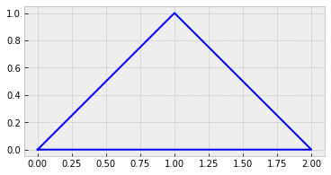

```python
import matplotlib.pyplot as plt
plt.style.use('bmh')

plt.plot(
    [0, 1, 2, 0],  # X-values
    [0, 1, 0, 0],   # Y-values
    color='blue'
)
plt.gca().set_aspect("equal")
plt.savefig('triangle.png')
```

**a.** (2 points)

Write a class `Rectangle`.

- include the attributes `base`, `height`, `color`, `perimeter`, `area`, and `vertices`.
  - only `base`, `height`, and `color` should be used as parameters
- include a method `describe()` that prints out the attributes of the rectangle.
- include a method `render()` that renders the rectangle on a cartesian plane. (You can use `plt.plot()` and `plt.gca()` and `plot.gca().set_aspect("equal")` as shown above.)

```
>>> rect = Rectangle(5,2,'red')
>>> rect.describe()
Base: 5
Height: 2
Color: red
Perimeter: 14
Area: 10
Vertices: [(0,0), (5,0), (5,2), (0,2)]
>>> rect.render()
```

[figure not shown]

**b.** (2 points)

Write a class `RightTriangle`.

- Include the attributes `base`, `height`, `color`, `perimeter`, `area`, and `vertices`.
- Include a method `describe()` that prints out the attributes of the right triangle.
- include a method `render()` that draws the triangle on a cartesian plane.

```
>>> tri = RightTriangle(5,2,'blue')
>>> tri.describe()
Base: 5
Height: 2
Color: blue
Perimeter: 12.3851648071
Area: 5
Vertices: [(0,0), (5,0), (0,2)]
>>> tri.render()
```

[figure not shown]

# Problem 11-1

**Location:** `assignment-problems/kl_divergence_for_monte_carlo_simulations.py`

**Grading:** 10 points total

The **Kullback–Leibler divergence** (or **relative entropy**) between two probability distributions $p(n)$ and $q(n)$ is defined as

\begin{align*} \mathcal{D}(p \, || \, q) = \sum\limits_{n \text{ such that} \\ p(n), q(n) \neq 0} p(n) \ln \left( \dfrac{p(n)}{q(n)} \right) \end{align*}

Intuitively, the divergence measures how "different" the two distributions are.

**a.** (4 points)

Write a function `kl_divergence(p, q)` that computes the KL divergence between two probability distributions `p` and `q`, represented as arrays. Test your function by `assert`ing that it passes the following test:

```
>>> p = [0.2, 0.5, 0, 0.3]
>>> q = [0.1, 0.8, 0.1, 0]
>>> kl_divergence(p,q)
-0.09637237851    (in your test, you can round to 6 decimal places)

Note: the computation for the above is
0.2*ln(0.2/0.1) + 0.5*ln(0.5/0.8)

we exclude the terms 0*ln(0/0.1) and 0.3*ln(0.3/0)
because we're only summing over terms where neither
p(n) nor q(n) is equal to 0
```

**b.** (4 points)

Compute the KL divergence where `p` is the Monte Carlo distribution and `q` is the true distribution for the number of heads in 8 coin tosses, using 1,000 samples in your Monte Carlo simulation (that's the default number from the previous assignment).

Then do the same computation with 100 samples, and then with 10,000 samples. Print out the results for all 3 computations:

```
>>> python assignment-problems/kl_divergence_for_monte_carlo_simulations.py

Testing KL Divergence... Passed!

Computing KL Divergence for MC Simulations...
100 samples --> KL Divergence = ___
1,000 samples --> KL Divergence = ___
10,000 samples --> KL Divergence = ___
```

**c.** (2 points)

In a comment in your code, write down what the general trend is and why:

```
# As the number of samples increases, the KL divergence approaches __________ because _______________________________.
```

# Problem 11-2

**Locations:**

> `machine-learning/src/matrix.py`  
> `machine-learning/tests/test_matrix.py`

**Grading:** 5 points for each passing test, 10 points code quality (so 20 points total)

**MINOR CODE UPDATES BEFORE YOU DO THE ACTUAL PROBLEM:**

Before you do this problem, you need to update some of your previous code so that you don't run into any mutation issues where running methods affects the underlying elements.

**a.** First, update your `copy()` method so that when it creates a copied matrix, it uses a completely separate array of elements (albeit with the same entries). You can do it like this:

```
def copy(self):
    copied_elements = [[entry for entry in row] for row in self.elements]
    return Matrix(copied_elements)
```

(The reason why we need to do this is that whenever Python sees any sort of assignment with an existing list, it doesn't actually make a separate copy of the list. It just "points" to the existing list. We want the copied elements to be *completely separate* from `self.elements`.)

**b.** Second, update your helper methods `self.swap_rows()`, `self.normalize_row()`, `self.clear_below()`, and `self.clear_above()` so that they don't affect the original matrix `self`. In these methods, instead of modifying `self.elements` you should create a copy of `self.elements`, modify the copy, and then return the matrix whose elements are the copy.

You will need to update your tests to use `A = A.swap_rows()`, `A = A.normalize_row()`, `A = A.clear_below()`, and `A = A.clear_above()` as follows:

```
>>> A = Matrix(elements = [[0, 1, 2],
                           [3, 6, 9],
                           [2, 6, 8]])
>>> A.get_pivot_row(0)
1

>>> A = A.swap_rows(0,1)
>>> A.elements
[[3, 6, 9]
 [0, 1, 2]
 [2, 6, 8]]

>>> A = A.normalize_row(0)
>>> A.elements
[[1, 2, 3]
 [0, 1, 2]
 [2, 6, 8]]

>>> A = A.clear_below(0)
>>> A.elements
[[1, 2, 3]
 [0, 1, 2]
 [0, 2, 2]]

>>> A = A.get_pivot_row(1)
1

>>> A = A.normalize_row(1)
>>> A.elements
[[1, 2, 3]
 [0, 1, 2]
 [0, 2, 2]]

>>> A = A.clear_below(1)
>>> A.elements
[[1, 2, 3]
 [0, 1, 2]
 [0, 0, -2]]

>>> A.get_pivot_row(2)
2

>>> A = A.normalize_row(2)
>>> A.elements
[[1, 2, 3]
 [0, 1, 2]
 [0, 0, 1]]

>>> A = A.clear_above(2)
>>> A.elements
[[1, 2, 0]
 [0, 1, 0]
 [0, 0, 1]]

>>> A = A.clear_above(1)
>>> A.elements
[[1, 0, 0]
 [0, 1, 0]
 [0, 0, 1]]
```

**THE ACTUAL PROBLEM:**

Extend your `Matrix` class to include a method `rref` that converts the matrix to reduced row echelon form. You should use the [row reduction](https://textbooks.math.gatech.edu/ila/row-reduction.html) algorithm, which goes like this:

```
create a copy of the original matrix
row_index = 0
for each col_index:
    if a pivot row exists for the col_index:

        if the pivot row is not the current row:
            swap the current row with the pivot row
            # now the current row is actually the pivot row

        normalize the pivot row so that the first nonzero entry is 1
        clear all entries below and above the pivot entry

        row_index += 1
```

Assert that your method passes the following tests:

```
>>> A = Matrix([[0, 1, 2],
                [3, 6, 9],
                [2, 6, 8]])
>>> A.rref().elements
[1, 0, 0]
[0, 1, 0]
[0, 0, 1]

>>> B = Matrix([[0, 0, -4, 0],
                [0, 0, 0.3, 0],
                [0, 2, 1, 0]])
>>> A.rref().elements
[0, 1, 0, 0]
[0, 0, 1, 0]
[0, 0, 0, 0]
```

To help you debug your implementation, here is a walkthrough of the above algorithm on the matrix $\begin{bmatrix} 0 & 1 & 2 \\ 3 & 6 & 9 \\ 2 & 6 & 8 \end{bmatrix}\mathbin{:}$

```
row_index = 0

looping through columns...

col_index = 0

    current matrix is
    [0,1,2]
    [3,6,9]
    [2,6,8]

    for col_index = 0, the pivot row has index 1
    this is different from row_index = 0, so we need to swap
    swapping, the matrix becomes
    [3,6,9]
    [0,1,2]
    [2,6,8]

    the pivot row now has index 0, same as row_index = 0
    normalizing the pivot row, the matrix becomes
    [1,2,3]
    [0,1,2]
    [2,6,8]

    the pivot entry is the 1 in the (0,0) position (i.e. top-left)
    clearing all entries above and below the pivot entry, the matrix becomes
    [1,2,3]
    [0,1,2]
    [0,2,2]

    row_index += 1
    so now we have row_index = 1

col_index = 1

    current matrix is
    [1,2,3]
    [0,1,2]
    [0,2,2]

    for col_index = 1, the pivot row has index 1, same as row_index=1
    so no swap is needed

    the pivot row is already normalized

    the pivot entry is the 1 in the (1,1) position (i.e. exact middle)
    clearing all entries above and below the pivot entry, the matrix becomes
    [1,0,-1]
    [0,1,2]
    [0,0,-2]

    row_index += 1
    so now we have row_index = 2

col_index = 2

    current matrix is
    [1,0,-1]
    [0,1,2]
    [0,0,-2]

    for col_index = 2, the pivot row has index 2, same as row_index=2
    so no swap is needed

    normalizing the pivot row, the matrix becomes
    [1,0,-1]
    [0,1,2]
    [0,0,1]

    the pivot entry is the 1 in the (2,2) position (i.e. bottom-right)
    clearing all entries above and below the pivot entry, the matrix becomes
    [1,0,0]
    [0,1,0]
    [0,0,1]

    row_index += 1
    so now we have row_index = 3

we've gone through all the columns, so we're done!
the result is
    [1,0,0]
    [0,1,0]
    [0,0,1]
```

Likewise, here is a walkthrough of the above algorithm on the matrix $\begin{bmatrix} 0 & 0 & -4 & 0 \\ 0 & 0 & 0.3 & 0 \\ 0 & 2 & 1 & 0 \end{bmatrix}\mathbin{:}$

```
row_index = 0

looping through columns...

col_index = 0

    current matrix is
    [0,0,-4,0]
    [0,0,0.3,0]
    [0,2,1,0]

    for col_index = 0, there is no pivot row
    so we move on

    we still have row_index = 0

col_index = 1

    current matrix is
    [0,0,-4,0]
    [0,0,0.3,0]
    [0,2,1,0]

    for col_index = 1, the pivot row has index 2
    this is different from row_index = 0, so we need to swap
    swapping, the matrix becomes
    [0,2,1,0]
    [0,0,0.3,0]
    [0,0,-4,0]

    the pivot row now has index 0, same as row_index = 0
    normalizing the pivot row, the matrix becomes
    [0,1,0.5,0]
    [0,0,0.3,0]
    [0,0,-4,0]

    the pivot entry is the 1 in the (0,1) position
    all entries above and the pivot entry are already cleared

    row_index += 1
    so now we have row_index = 1

col_index = 2

    current matrix is
    [0,1,0.5,0]
    [0,0,0.3,0]
    [0,0,-4,0]

    for col_index = 2, the pivot row has index 1, same as row_index = 1
    so no swap is needed

    normalizing the pivot row, the matrix becomes
    [0,1,0.5,0]
    [0,0,1,0]
    [0,0,-4,0]

    the pivot entry is the 1 in the (1,2) position
    clearing all entries above and below the pivot entry, the matrix becomes
    [0,1,0,0]
    [0,0,1,0]
    [0,0,0,0]

    row_index += 1
    so now we have row_index = 2

col_index = 3

    current matrix is
    [0,1,0,0]
    [0,0,1,0]
    [0,0,0,0]

    for col_index = 3, there is no pivot row
    so we move on

    we still have row_index = 2

we've gone through all the columns, so we're done!
the result is
    [0,1,0,0]
    [0,0,1,0]
    [0,0,0,0]
```

# Problem 10-1

**Location:** `assignment-problems/distribution_plots.py`

**Grading:** 6 points

Using your function `probability(num_heads, num_flips)`, plot the distribution for the number of heads in `8` coin flips. In other words, plot the curve $y=p(x),$ where $p(x)$ is the probability of getting $x$ heads in $8$ coin flips.

Then, make **5** more plots, each using your function `monte_carlo_probability(num_heads, num_flips)`. Put all your plots on the same graph, label them with a legend to indicate whether each plot is the true distribution or a monte carlo simulation, and save the figure as `plot.png`.

> Legend: True, MC 1, MC 2, MC 3, MC 4, MC 5.

Make the true distribution thick (`linewidth=2.5`) and the monte carlo distributions thin (`linewidth=0.75`). A plotting example for 4 coin flips is shown below to assist you.

- **Note: You will need to modify the plotting example to make it for 8 coin flips instead of 4.**
- To be clear, you are just making 1 plot. The plot should contain the true distribution (thick line) and 5 Monte Carlo simulation distributions (thin lines).

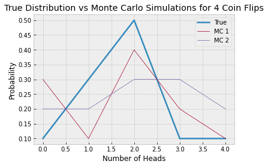

```python
import matplotlib.pyplot as plt
plt.style.use('bmh')
plt.plot([0,1,2,3,4],[0.1, 0.3, 0.5, 0.1, 0.1],linewidth=2.5)
plt.plot([0,1,2,3,4],[0.3, 0.1, 0.4, 0.2, 0.1],linewidth=0.75)
plt.plot([0,1,2,3,4],[0.2, 0.2, 0.3, 0.3, 0.2],linewidth=0.75)
plt.legend(['True','MC 1','MC 2'])
plt.xlabel('Number of Heads')
plt.ylabel('Probability')
plt.title('True Distribution vs Monte Carlo Simulations for 4 Coin Flips')
plt.savefig('plot.png')
```

# Problem 10-2

**Locations:** `assignment-problems/unlist.py`

**Grading:** In each part, you get 1 point for code quality, and 1 point for passing tests (so 4 points total)

**a.** **WITHOUT using recursion,** create a function `unlist_nonrecursive(x)` that removes outer parentheses from a list until either a) the final list consists of multiple elements, or b) no more lists exist.

Assert that your function passes the following tests.

```
>>> unlist_nonrecursive([[[[1], [2,3], 4]]])
[[1], [2,3], 4]
>>> unlist_nonrecursive([[[[1]]]])
1
```

**b.** **USING RECURSION,** write a function `unlist_recursive(x)` and assert that it passes the same tests as in part (a).

# Problem 9-1

**Locations:** `assignment-problems/collatz_iterations.py`

The *Collatz function* is defined as

$$f(n) = \begin{cases} n \, / \, 2 & \text{if } n \text{ is even} \\ 3n+1 & \text{if } n \text{ is odd} \end{cases}$$

The *Collatz conjecture* is that by repeatedly applying this function to any positive number, the result will eventually reach the cycle

$$1 \to 4 \to 2 \to 1.$$

For example, repeatedly applying the Collatz function to the number $13,$ we have:

$$13 \to 40 \to 20 \to 10 \to 5 \to 16 \to 8 \to 4 \to 2 \to 1$$

**a.** (1 point for code quality; 1 point for passing the test)

Create a function `collatz_iterations(number)` that computes the number of iterations of the Collatz function that it takes for the input number to reach $1.$

```
>>> collatz_iterations(13)
9
```

**b.** (1 point)

Write a short script to answer the following question:

> Of the numbers from 1 to 1000, which number has the highest number of Collatz iterations?

**c.** (1 point)

Make a plot where the horizontal axis is the numbers from 1 to 1000 and the vertical axis is the number of Collatz iterations. You can use the sample code below to help you with plotting.

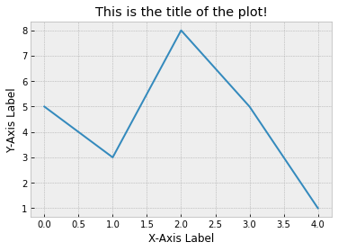

```python
import matplotlib.pyplot as plt
plt.style.use('bmh')
x_coords = [0,1,2,3,4]
y_coords = [5,3,8,5,1]
plt.plot(x_coords, y_coords)
plt.xlabel('X-Axis Label')
plt.ylabel('Y-Axis Label')
plt.title('This is the title of the plot!')
plt.savefig('plot.png')
```

# Problem 9-2

This will be a lighter assignment in case you need to catch up with the Matrix class or the Monte Carlo simulations. They need to be working 100%. Make sure that you've caught up, because we will be pressing forward with them on the next few assignments.

# Problem 8-1

**Locations:** `machine-learning/src/matrix.py` and `machine-learning/tests/test_matrix.py`

**Grading:** 5 points for code quality; 5.5 points for passing tests (0.5 point per test)

**Implement the following helper methods in your matrix class.**

- `get_pivot_row(self, column_index)`: returns the index of the topmost row that has a nonzero entry in the desired `column_index` and such that all entries left of `column_index` are zero. Otherwise, if no row exists, return `None`.
- `swap_rows(self, row_index1, row_index2)`: swap the row at `row_index1` with the row at `row_index2`.
- `normalize_row(self, row_index)`: divide the entire row at `row_index` by the row's first nonzero entry.
- `clear_below(self, row_index)`:
  - Let $j$ be the column index of the first nonzero entry in the row at `row_index`.
  - Subtract multiples of the row at `row_index` from the rows below, so that for any row below `row_index`, the entry at column $j$ is zero.
- `clear_above(self, row_index)`:
  - Let $j$ be the column index of the first nonzero entry in the row at `row_index`.
  - Subtract multiples of the row at `row_index` from the rows above, so that for any row above `row_index`, the entry at column $j$ is zero.

**Watch out!**

- Remember that the first row/column of a matrix has the index `0`, not `1`.
- If `row1` is "below" `row2` in a matrix, then `row1` actually has a higher index than `row2`. This is because the `0` index corresponds to the very top row.

**Assert that the following tests pass.**

```
>>> A = Matrix(elements = [[0, 1, 2],
                           [3, 6, 9],
                           [2, 6, 8]])
>>> A.get_pivot_row(0)
1

>>> A = A.swap_rows(0,1)
>>> A.elements
[[3, 6, 9]
 [0, 1, 2]
 [2, 6, 8]]

>>> A = A.normalize_row(0)
>>> A.elements
[[1, 2, 3]
 [0, 1, 2]
 [2, 6, 8]]

>>> A = A.clear_below(0)
>>> A.elements
[[1, 2, 3]
 [0, 1, 2]
 [0, 2, 2]]

>>> A = A.get_pivot_row(1)
1

>>> A = A.normalize_row(1)
>>> A.elements
[[1, 2, 3]
 [0, 1, 2]
 [0, 2, 2]]

>>> A = A.clear_below(1)
>>> A.elements
[[1, 2, 3]
 [0, 1, 2]
 [0, 0, -2]]

>>> A.get_pivot_row(2)
2

>>> A = A.normalize_row(2)
>>> A.elements
[[1, 2, 3]
 [0, 1, 2]
 [0, 0, 1]]

>>> A = A.clear_above(2)
>>> A.elements
[[1, 2, 0]
 [0, 1, 0]
 [0, 0, 1]]

>>> A = A.clear_above(1)
>>> A.elements
[[1, 0, 0]
 [0, 1, 0]
 [0, 0, 1]]
```

Make sure that when you run `python tests/test_matrix.py`, your tests print out (including your tests from last time)

```
>>> python tests/test_matrix.py
Testing method "copy"...
PASSED

Testing method "add"...
PASSED

Testing method "subtract"...
PASSED

Testing method "scalar_multiply"...
PASSED

Testing method "matrix_multiply"...
PASSED

Testing row reduction on the following matrix:
[[0, 1, 2],
 [3, 6, 9],
 [2, 6, 8]]

- Testing method "get_pivot_row(0)"...
- PASSED

- Testing method "swap_rows(0,1)"...
- PASSED

- Testing method "normalize_row(0)"...
- PASSED

- Testing method "clear_below(0)"...
- PASSED

- Testing method "get_pivot_row(1)"...
- PASSED

- Testing method "normalize_row(1)"...
- PASSED

- Testing method "clear_below(1)"...
- PASSED

- Testing method "get_pivot_row(2)"...
- PASSED

- Testing method "normalize_row(2)"...
- PASSED

- Testing method "clear_above(2)"...
- PASSED

- Testing method "clear_above(1)"...
- PASSED
```

# Problem 8-2

**Locations:** `assignment-problems/further_comprehensions.py`

**Grading:** 2 points for each part

**a.** **USING COMPREHENSION**, create a function `identity_matrix_elements(n)` that creates the elements for an $n \times n$ identity matrix. **The body of your function should consist of just 1 line, in which it simply returns a list comprehension.**

Assert that your function passes the following test:

```
>>> identity_matrix_elements(4)
[[1, 0, 0, 0],
 [0, 1, 0, 0],
 [0, 0, 1, 0],
 [0, 0, 0, 1]]
```

- **Hint:** `[[(some expression) for each column index] for each row index]`

**b.** **USING COMPREHENSION**, create a function `counting_across_rows_matrix_elements(m,n)` that creates the elements for an $m \times n$ matrix that "counts" upwards across the rows. **The body of your function should consist of just 1 line, in which it simply returns a list comprehension.**

Assert that your function passes the following test:

```
>>> counting_across_rows_matrix_elements(3,4)
[[1, 2, 3, 4],
 [5, 6, 7, 8],
 [9, 10, 11, 12]]
```

- **Hint:** `[[(some expression) for each column index] for each row index]`

**Note:** Try to do these problems without without using any separate functions in the `(some expression)` part. But if you can't figure it out, you can define an outside function to use there, and I won't take off points.

# Problem 7-1

**Grading:** 1 point per working test with good code quality. (There are 7 tests total)

Generalize your `Matrix` class to $M \times N$ matrices. Also, write two more methods `transpose()` and `is_equal()`, and create attributes `num_rows` and `num_cols`.

Assert that the following tests work. Put your tests in `machine-learning/tests/test_matrix.py`.

**Note:** In the tests below, we manipulate a $4 \times 5$ matrix. However, your code should be general to *any* size of matrix. For example, it should work with a $400 \times 500$ matrix as well.

```
>>> A = Matrix([[1,0,2,0,3],
                [0,4,0,5,0],
                [6,0,7,0,8],
                [-1,-2,-3,-4,-5])
>>> (A.num_rows, A.num_cols)
(4, 5)

>>> A_t = A.transpose()
>>> A_t.elements
[[ 1,  0,  6, -1],
 [ 0,  4,  0, -2],
 [ 2,  0,  7, -3],
 [ 0,  5,  0, -4],
 [ 3,  0,  8, -5]]

>>> B = A_t.matrix_multiply(A)
>>> B.elements
[[38,  2, 47,  4, 56],
 [ 2, 20,  6, 28, 10],
 [47,  6, 62, 12, 77],
 [ 4, 28, 12, 41, 20],
 [56, 10, 77, 20, 98]]

>>> C = B.scalar_multiply(0.1)
>>> C.elements
[[3.8,  .2, 4.7,  .4, 5.6],
 [ .2, 2.0,  .6, 2.8, 1.0],
 [4.7,  .6, 6.2, 1.2, 7.7],
 [ .4, 2.8, 1.2, 4.1, 2.0],
 [5.6, 1.0, 7.7, 2.0, 9.8]]

>>> D = B.subtract(C)
>>> D.elements
[[34.2,  1.8, 42.3,  3.6, 50.4]
 [ 1.8, 18. ,  5.4, 25.2,  9. ]
 [42.3,  5.4, 55.8, 10.8, 69.3]
 [ 3.6, 25.2, 10.8, 36.9, 18. ]
 [50.4,  9. , 69.3, 18. , 88.2]]

>>> E = D.add(C)
[[38,  2, 47,  4, 56],
 [ 2, 20,  6, 28, 10],
 [47,  6, 62, 12, 77],
 [ 4, 28, 12, 41, 20],
 [56, 10, 77, 20, 98]]

>>> (E.is_equal(B), E.is_equal(C))
(True, False)
```

**Tip:** For `matrix_multiply`, make a helper function dot_product that computes a dot product of two lists. Then just loop through each row-column pair and compute the corresponding dot product.

**Note:** When you multiply 38 by 0.1, you might get a result like 3.80000000...3.

This is because of the way that Python represents numbers -- decimal numbers are always close *approximations* to the real thing, since there's a limit to how many digits the computer can store. So, it's normal.

However, that does make it more difficult to write a test to make sure that a matrix equals the desired result. So what you can do to get around it is you can implement a round method for your matrix, and then assert that your matrix elements (rounded to, say, 5 decimal places) come out to the desired result.

```
class Matrix

  ...

  def round(self, num_decimal_places):
     return self.elements rounded to num_decimal_places
```

```
scalar_product_matrix = original_matrix.scalar_multiply(0.1)
assert scalar_product_matrix.round(5) == desired_result
```

For rounding, there's a built-in function `round()`. For example,

```
>>> round(0.45982345, 4)
0.4598
```

# Problem 7-2

**Location:** `assignment-problems/monte_carlo_coin_flips.py`

**Grading:** There are 6 points possible (2 points per part).

In this problem, you will compute the probability of getting `num_heads` heads in `num_flips` flips of a fair coin. You will do this using two different methods. You should write your functions in a file `assignment-problems/coin_flipping.py`

**a.** (1 point for code quality; 1 point for passing test)

Write a function `probability(num_heads, num_flips)` that uses mathematics to compute the probability.

- First, compute the total number of possible outcomes for `num_flips` flips. (Hint: it's an exponent.)
- Then, compute the number of outcomes in which `num_heads` heads arise in `num_flips` flips. (Hint: it's a combination.)
- Then, divide the results.
- For a `factorial` function and or a `binomial_coefficient` function, write your own from scratch.

Assert that your function passes the following test:

```
>>> probability(5,8)
0.21875
```

**b.** (2 points for code quality/correctness)

Write a function `monte_carlo_probability(num_heads, num_flips)` that uses simulation to compute the probability.

- First, simulate 1000 trials of `num_flips` coin flips, keeping track of how many heads there were.
- Then, divide the number of outcomes in which there were `num_heads` heads, by the total number of trials (1000).
- You can use the `random()` function from the `random` library:

  ```
  >>> from random import random
  >>> random()
  (some random number between 0 and 1)
  ```

**c.** (1 point for code quality; 1 point for printing out reasonable monte carlo results)

When you run `assignment-problems/monte_carlo_coin_flips.py`, you should print out the result of `probability(5,8)`. Also, print out 5 instances of `monte_carlo_probability(5,8)`.

- The 5 instances will be slightly different because it's a random simulation, but they should be fairly close to each other and to the true result.

# Problem 7-3

**Location:** `assignment-problems/swap_sort_theory.txt`

**Grading:** 1 point per correct answer **with justification.**

Answer the following questions about `swap_sort`. *Explain or show your work for each question.*

> a. Given a list of 5 elements, what’s the least number of swaps that could occur? What about for a list of $n$ elements? **Explain why.**

> b. Given a list of 5 elements, what’s the greatest number of swaps that could occur? What about for a list of $n$ elements? **Explain why.**

For (c) and (d), determine whether the statement is true or false. If true, then explain why. If false, then provide a counterexample.

> c. The number of swaps performed by swap sort on each pass is always a decreasing sequence.

> d. On two consecutive passes, the number of swaps performed by swap sort is never equal.

# Problem 6-1

**Locations:** `machine-learning/src/matrix.py` and `machine-learning/tests/test_matrix.py`

**Grading:** 5 points for code quality; 5 points for passing each test (1 point per test)

**Note:** You are **NOT** allowed to use `numpy` or any other external library. The `Matrix` class should be written entirely from scratch.

1. Create a `machine-learning` repository on GitHub and connect it to a repl of the same name. Create a folder `machine-learning/src`, and within that folder, put a file `matrix.py` which will contain the `Matrix` class you write in this problem.
2. In `machine-learning/src/matrix.py`, create a `Matrix` class with the methods `copy`, `add`, and `subtract`, `scalar_multiply`, and `matrix_multiply` for $2 \times 2$ matrices.
3. Create a folder `machine-learning/tests`, and within that folder, put a file `test_matrix.py` which will contain your "assert" tests for the `Matrix` class.
4. In `machine-learning/tests/test_matrix.py`, include the following at the top of your file so that you can use your `Matrix` class:

```
import sys
sys.path.append('src')
from matrix import Matrix
```

1. In `machine-learning/tests/test_matrix.py`, assert that your `Matrix` class passes the following tests:

```
>>> A = Matrix([[1,3],
                [2,4]])
>>> A.elements
[[1,3],
 [2,4]]

>>> B = A.copy()
>>> A = 'resetting A to a string'
>>> B.elements # the purpose of this test is to show that B is independent of A
[[1,3],
 [2,4]]

>>> C = Matrix([[1,0],
                [2,-1]])
>>> D = B.add(C)
>>> D.elements
[[2,3],
 [4,3]]

>>> E = B.subtract(C)
>>> E.elements
[[0,3],
 [0,5]]

>>> F = B.scalar_multiply(2)
>>> F.elements
[[2,6],
 [4,8]]

>>> G = B.matrix_multiply(C)
[[7,-3],
 [10,-4]]
```

1. Make sure that when you run `python tests/test_matrix.py`, your tests print out:

```
>>> python tests/test_matrix.py
Testing method "copy"...
PASSED

Testing method "add"...
PASSED

Testing method "subtract"...
PASSED

Testing method "scalar_multiply"...
PASSED

Testing method "matrix_multiply"...
PASSED
```

# Problem 6-2

**Locations:** `assignment-problems/skip_factorial.py`

**Grading:** For each part, you get 1 point for code quality and 1 point for passing both tests.

**a.** **WITHOUT using recursion,** create a function `skip_factorial_nonrecursive(n)` that computes the product

- $n(n-2)(n-4)\ldots(2)$ if $n$ is even, or
- $n(n-2)(n-4)\ldots(1)$ if $n$ is odd.

Assert that your function passes the following tests:

```
>>> skip_factorial_nonrecursive(6)
48
>>> skip_factorial_nonrecursive(7)
105
```

**b.** **USING RECURSION,** create a function `skip_factorial_recursive(n)` and assert that it passes the same tests as in part (a).

# Problem 6-3

**Locations:** `assignment-problems/simple_sort_swap_sort.py`

**Note:** In these questions, you will need to compute the minimum element of a list **without using Python's built-in `min` function**. To do this, you should write a "helper" function `minimum()` that loops through a list, keeping track of the smallest element seen so far. For example:

```
given the list [4,6,3,5]
first element is 4; smallest element so far is 4
next element is 6; smallest element so far is 4
next element is 3; smallest element so far is 3
next element is 5; smallest element so far is 3
conclude that minimum element is 3
```

**a.** (1 point for code quality, 1 point for passing test)

Write a function `simple_sort(num_list)` that takes an input list `num_list` and sorts its elements from least to greatest by repeatedly finding the smallest element and moving it to a new list. **Don't use Python's built-in `min` function or its built-in `sort` function.**

Assert that your function passes the following test:

```
>>> simple_sort([5,8,2,2,4,3,0,2,-5,3.14,2])
[-5,0,2,2,2,2,3,3.14,4,5,8]
```

**Tip:** To help you debug your code, here are the steps that your function should be doing behind the scenes. (You don't have to write tests for them.)

[output not shown]

**b.** (1 point for code quality, 1 point for passing test)

Write a function `swap_sort(x)` that sorts the list from least to greatest by repeatedly going through each pair of adjacent elements and swapping them if they are in the wrong order. The algorithm should terminate once it's made a full pass through the list without making any more swaps. **Don't use Python's built-in `sort` function.**

Assert that your function passes the following test:

```
>>> swap_sort([5,8,2,2,4,3,0,2,-5,3.14,2])
[-5,0,2,2,2,2,3,3.14,4,5,8]
```

**Tip:** To help you debug your code, here are the steps that your function should be doing behind the scenes. (You don't have to write tests for them.)

[output not shown]

# Problem 5-1

**Location:** `assignment-problems/comprehensions.py`

**Grading:** 2 points for each part (a) and (b)

**a.** Implement a function `even_odd_tuples` that takes a list of numbers and labels each number as even or odd. Return a [list comprehension](https://www.python-course.eu/list_comprehension.php) so that the function takes up only two lines, as follows:

```
def even_odd_tuples(numbers):
   return [<your code here>]
```

Assert that your function passes the following test:

```
>>> even_odd_tuples([1,2,3,5,8,11])
[(1,'odd'),(2,'even'),(3,'odd'),(5,'odd'),(8,'even'),(11,'odd')]
```

**b.** Implement a function `even_odd_dict` that again takes a list of numbers and labels each number as even or odd. This time, the output will be a dictionary. Use a [dictionary comprehensions](https://www.geeksforgeeks.org/python-dictionary-comprehension/) so that the function takes up only two lines, as follows:

```
def even_odd_dict(numbers):
   return {<your code here>}
```

Assert that your function passes the following test:

```
>>> even_odd_dict([1,2,3,5,8,11])
{
    1:'odd',
    2:'even',
    3:'odd',
    5:'odd',
    8:'even',
    11:'odd'
}
```

# Problem 5-2

**Location:** `assignment-problems/root_approximation.py`

**Grading:** For each part (a) and (b), you get 2 points for code quality and 2 points for passing the tests. So there are 8 points in total to be had on this problem.

The value of $\sqrt{2}$ is in the interval $[1,2].$ We will estimate the value of $\sqrt{2}$ by repeatedly narrowing these bounds.

**a.** Create a function `update_bounds(bounds)` that guesses a value halfway between the bounds, determines whether the guess was too high or too low, and updates the `bounds` accordingly.

- For example, starting with the bounds $[1,2],$ the guess would be $1.5.$ This guess is too high because $1.5^2 = 2.25 > 2.$ So, the updated bounds would be $[1, 1.5].$
- Now, using the bounds $[1,1.5]$, the next guess would be $1.25.$ This guess is too low because $1.25^2 = 1.5625 < 2.$ So, the updated bounds would be $[1.25, 1.5].$

Assert that your function passes the following tests:

```
>>> update_bounds([1, 2])
[1, 1.5]
>>> update_bounds([1, 1.5])
[1.25, 1.5]
```

**b.** Write a function `estimate_root(precision)` that estimates the value of $\sqrt{2}$ by repeatedly calling `update_bounds` until the bounds are narrower than `precision`. You can start with the bounds $[1,2]$ again. Then it should return the midpoint of the final set of bounds.

Assert that your function passes the following test:

```
>>> estimate_root(0.1)
1.40625

note: the sequence of bounds would be
[1, 2]
[1, 1.5]
[1.25, 1.5]
[1.375, 1.5]
[1.375, 1.4375]
```

# Problem 5-3

**Location:** `assignment-problems/queue.py`

**Grading:** you get 0.5 points for passing each test, and 2 points for code quality

Implement a queue. That is, create a class `Queue` which operates on an attribute `data` using the following methods:

- `enqueue`: add a new item to the back of the queue
- `dequeue`: remove the item at the front of the queue
- `peek`: return the item at the front without modifying the queue

Assert that the following tests pass:

```
>>> q = Queue()
>>> q.data
[]
>>> q.enqueue('a')
>>> q.enqueue('b')
>>> q.enqueue('c')
>>> q.data
['a', 'b', 'c']
>>> q.dequeue()
>>> q.data
['b', 'c']
>>> q.peek()
'b'
>>> q.data
['b', 'c']
```

# Problem 4-1

**Location:** `assignment-problems/flatten.py`

**Grading:** 1 point for passing test, and then (assuming it passes the test) 1 point for code quality

Write a function `flatten` which takes a nested dictionary and converts it into a flat dictionary based on the key names. You can assume that the nested dictionary only has one level of nesting, meaning that in the output, each key will have exactly one underscore.

Assert that your function passes the following test:

```
>>> colors = {
  'animal': {
    'bumblebee': ['yellow', 'black'],
    'elephant': ['gray'],
    'fox': ['orange', 'white']
  },
  'food': {
    'apple': ['red', 'green', 'yellow'],
    'cheese': ['white', 'orange']
  }
}
>>> flatten(colors)
{
  'animal_bumblebee': ['yellow', 'black'],
  'animal_elephant': ['gray'],
  'animal_fox': ['orange', 'white'],
  'food_apple': ['red', 'green', 'yellow'],
  'food_cheese': ['white', 'orange']
}
```

# Problem 4-2

**Location:** `assignment-problems/convert_to_base_2.py`

**Grading:** 1 point for passing test, and then (assuming it passes the test) 1 point for code quality

Write a function `convert_to_base_2` that converts a number from base-10 to base-2. Assert that it passes the following test:

```
>>> convert_to_base_2(19)
10011
```

Hint: use $\log_2$ to figure out how many digits there will be in the binary number. Then, fill up the binary number, repeatedly subtracting off the next-largest power of 2 if possible.

# Problem 4-3

**Location:** `assignment-problems/linear_encoding_cryptography.py`

**Grading:** for each part, you get 1 point for passing test, and then (assuming it passes the test) 1 point for code quality

In Assignment 1, we encountered the trivial encoding function which maps

- `' '` $\rightarrow 0,$
- `'a'` $\rightarrow 1,$
- `'b'` $\rightarrow 2,$

and so on.

Using a linear encoding function $s(x) = 2x+3,$ the message `'a cat'` can be encoded as follows:

1. Original message: `'a cat'`
2. Trivial encoding: `[1, 0, 3, 1, 20]`
3. Linear encoding: `[5, 3, 9, 5, 43]`

**a.** Create a function `encode(string,a,b)` which encodes a string using the linear encoding function $s(x) = ax+b.$ Assert that your function passes the following test:

```
>>> get_encoding('a cat', 2, 3)
[5, 3, 9, 5, 43]
```

**b.** Create a function `decode(numbers,a,b)` which attempts to decode a given list of `numbers` using the linear encoding function $s(x) = ax+b.$

To do this, you should apply the inverse encoding $s^{-1}(x) = \dfrac{x-b}{a},$ to all the numbers in the list and then check if they are all integers in the range from $0$ to $26$ (inclusive). If they are, then return the corresponding letters; if they are not, then return False.

Assert that your function passes the following tests:

```
>>> decode([5, 3, 9, 5, 43], 2, 3)
'a cat'

for debugging purposes, here's the scratch work for you:
[(5-3)/2, (3-3)/2, (9-3)/2, (5-3)/2, (43-3)/2]
[1, 0, 3, 1, 20]
'a cat'

>>> decode([1, 3, 9, 5, 43], 2, 3)
False

for debugging purposes, here's the scratch work for you:
[(1-3)/2, (3-3)/2, (9-3)/2, (5-3)/2, (43-3)/2]
[-1, 0, 3, 1, 20]
False (because -1 does not correspond to a letter)

>>> decode([5, 3, 9, 5, 44], 2, 3)
False

for debugging purposes, here's the scratch work for you:
[(5-3)/2, (3-3)/2, (9-3)/2, (5-3)/2, (44-3)/2]
[1, 0, 3, 1, 20.5]
False (because 20.5 does not correspond to a letter)
```

**c.** Decode the message

```
[377,
 717,
 71,
 513,
 105,
 921,
 581,
 547,
 547,
 105,
 377,
 717,
 241,
 71,
 105,
 547,
 71,
 377,
 547,
 717,
 751,
 683,
 785,
 513,
 241,
 547,
 751],
```

given that it was encoded with a linear encoding function $s(x) = ax+b$ where $a,b \in \{ 0, 1, 2, \ldots, 100 \}.$

You should run through each combination of $a$ and $b,$ try to decode the list of numbers using that combination, and if you get a valid decoding, then print it out. Then, you can visually inspect all the decodings you printed out to find the one that makes sense.

# Problem 3-1

**Location:** `assignment-problems/convert_to_base_10.py`

**Grading:** 1 point for passing test, and then (assuming it passes the test) 1 point for code quality

Write a function `convert_to_base_10` that converts a number from base-2 (binary) to base-10 (decimal). For example, the binary number $10011$ corresponds to the decimal number $$ 1 \cdot 2^{4} + 0 \cdot 2^3 + 0 \cdot 2^2 + 1 \cdot 2^1 + 1 \cdot 2^0 = 19. $$

Assert that your function passes the following test:

```
>>> convert_to_base_10(10011)
19
```

# Problem 3-2

**Location:** `assignment-problems/make_nested.py`

**Grading:** you get 1 point for passing the test, and then (assuming it passes the test) 1 point for code quality

Write a function `make_nested` which takes a "flat" dictionary and converts it into a nested dictionary based on underscores in the the key names. You can assume that all keys have exactly one underscore.

Assert that your function passes the following test:

```
>>> colors = {
  'animal_bumblebee': ['yellow', 'black'],
  'animal_elephant': ['gray'],
  'animal_fox': ['orange', 'white'],
  'food_apple': ['red', 'green', 'yellow'],
  'food_cheese': ['white', 'orange']
  }
>>> make_nested(colors)
{
  'animal': {
    'bumblebee': ['yellow', 'black'],
    'elephant': ['gray'],
    'fox': ['orange', 'white']
  },
  'food': {
    'apple': ['red', 'green', 'yellow'],
    'cheese': ['white', 'orange']
  }
}
```

# Problem 3-3

**Location:** `assignment-problems/stack.py`

**Grading:** you get 0.5 points for passing each test, and then (assuming your code passes all the tests) 2 points for code quality.

Implement a stack). That is, create a class `Stack` which operates on an attribute `data` using the following methods:

- `push`: add a new item on top of the stack
- `pop`: remove the top (rightmost) item from the stack
- `peek`: return the top item without modifying the stack

Assert that your class passes the following sequence of 5 tests. (You should write 5 `assert` statements in total.)

```
>>> s = Stack()
>>> s.data
[]
>>> s.push('a')
>>> s.push('b')
>>> s.push('c')
>>> s.data
['a', 'b', 'c']
>>> s.pop()
>>> s.data
['a', 'b']
>>> s.peek()
'b'
>>> s.data
['a', 'b']
```

# Problem 2-1

**Location: `assignment-problems/union_intersection.py`**

**a.** (1 point for code quality; 1 point for passing test)

Write a function `intersection` that computes the intersection of two lists. Assert that it passes the following test:

```
>>> intersection([1,2,'a','b'], [2,3,'a'])
[2,'a']
```

**b.** (1 point for code quality; 1 point for passing test)

Write a function `union` that computes the union of two lists. Assert that it passes the following test:

```
>>> union([1,2,'a','b'], [2,3,'a'])
[1,2,3,'a','b']
```

# Problem 2-2

**Location: `assignment-problems/count_characters.py`**

(2 points for code quality; 2 points for passing test)

Write a function `count_characters` that counts the number of each character in a string and returns the counts in a dictionary. Lowercase and uppercase letters should not be treated differently.

Assert that your function passes the following test:

```
>>> countCharacters('A cat!!!')
{'a': 2, 'c': 1, 't': 1, ' ': 1, '!': 3}
```

# Problem 2-3

**Location: `assignment-problems/recursive_sequence.py`**

Consider the sequence defined recursively as

$$a_n = 3a_{n-1} -4, \quad a_1 = 5.$$

**a.** (1 point for code quality; 1 point for passing test)

Write a function `first_n_terms` that returns a list of the first $n$ terms of the sequence: $[a_1, a_2, a_3, \ldots, a_{n}]$

Assert that your function passes the following test:

```
>>> first_n_terms(10)
[5, 11, 29, 83, 245, 731, 2189, 6563, 19685, 59051]
```

**b.** (1 point for code quality; 1 point for passing test)

Write a function `nth_term` that computes the $n$th term of the sequence using recursion. Here's the video that you were asked to watch before class, in case you need to refer back to it: https://www.youtube.com/watch?v=zbfRgC3kukk

Assert that your function passes the following test:

```
>>> nth_term(10)
59051
```

# Problem 1-1

Getting started...

1. Join [eurisko-us.slack.com](https://join.slack.com/t/eurisko-us/shared_invite/zt-givjn7g3-gNSRb5ILFECayafVLunUrg)
2. Sign up for [repl.it](https://repl.it/)
3. Create a bash repl named `assignment-problems`
4. Create a file `assignment-problems/test_file.py`
5. Sign up for github.com
6. On repl.it, link `assignment-problems` to your github and push up your work to github. Name your commit "test commit".
7. After you complete this assignment, again push your work up to github. Name your commit "completed assignment 1".

# Problem 1-2

**Location: `assignment-problems/is_symmetric.py`**

**Note: This problem is worth 1 point for passing both tests, plus another 1 point for code quality (if you pass the tests). So, the rubric is as follows:**

- 0/2 points: does not pass both tests
- 1/2 points: passes both tests but code is poor quality
- 2/2 points: passes both tests and code is high quality

Write a function `is_symmetric(input_string)` that checks if a string reads the same forwards and backwards, and `assert` that your function passes the following tests:

```
>>> is_symmetric('racecar')
True
>>> is_symmetric('batman')
False
```

To be clear -- when you run `is_symmetric.py`, your code should print the following:

```
>>> python is_symmetric.py

testing is_symmetric on input 'racecar'...
PASSED

testing is_symmetric on input 'batman'...
PASSED
```

# Problem 1-3

**Location: `assignment-problems/letters_numbers_conversion.py`**

**a.** (1 point for passing test, 1 point for code quality)

Write a function `convert_to_numbers(input_string)` that converts a string to a list of numbers, where space = 0, a = 1, b = 2, and so on. Then, `assert` that your function passes the following test:

```
>>> letters2numbers('a cat')
[1,0,3,1,20]
```

**b.** (1 point for code quality, 1 point for passing test)

Write a function `convert_to_letters(input_string)` that converts a list of numbers to the corresponding string, and `assert` that your function passes the following test:

```
>>> convert_to_letters([1,0,3,1,20])
'a cat'
```

To be clear -- when you run `letters_numbers_conversion.py`, your code should print the following:

[output not shown]

# Problem 1-4

(2 points for passing tests, 2 points for code quality)

Write a function `is_prime(n)` that checks if an integer input $n > 1$ is prime by checking whether $m | n$ for any integer $m \in \left\{ 2, 3, \ldots, \left\lfloor \dfrac{n}{2} \right\rfloor \right\}.$

- $m|n$ means "$m$ divides $n$"
- $\left\lfloor \dfrac{n}{2} \right\rfloor$ is called the "floor" of $\dfrac{n}{2},$ i.e. the greatest integer that is less than or equal to $\dfrac{n}{2}.$

(Hint: Check for divisibility within a for loop.)

Also, `assert` that your function passes the following tests:

```
>>> is_prime(59)
True
>>> is_prime(51)
False
```

To be clear -- when you run `is_prime.py`, your code should print the following:

```
>>> python is_prime.py

testing is_prime on input 59...
PASSED

testing is_prime on input 51...
PASSED
```